# Analysis of RNG/gesture data

Bodo

2023-03-23

# 1 Introduction

This script analyses the Italian and English random number generation (RNG) data together in one go.

# 2 Setup

Load packages:

```r
library(tidyverse)    # for all data processing and data viz
library(patchwork)    # for double plots
library(brms)         # for Bayesian regression models
library(tidybayes)    # for stat_halfeye() function
library(effsize)      # for Cohen's d
library(pwr)          # for effect size sensitivity analysis / power analysis
```

*Note*: The `stat_halfeye()` function does not feature on any of the published plots, hence we’re not citing it in the paper.

For reproducibility report versions:

```r
R.Version()$version.string
```

```
## [1] "R version 4.4.0 (2024-04-24)"
```

```r
packageVersion('tidyverse')
```

```
## [1] '2.0.0'
```

```r
packageVersion('brms')
```

```
## [1] '2.21.0'
```

```r
packageVersion('tidybayes')
```

```
## [1] '3.0.6'
```

```r
packageVersion('effsize')
```

```
## [1] '0.8.1'
```

```r
packageVersion('pwr')
```

```
## [1] '1.3.0'
```

Load data:

```r
# Experiment data, English:

eng_2023 <- read_csv('../data/RNG_eng_first_bout_2023.csv')
eng_2024 <- read_csv('../data/RNG_eng_second_bout_2024.csv') |>
  rename(id = `Participant ID`,
         trial = order,
         movement = Movement,
         number = Number)

# Experiment data, Italian:

ita_2023 <- read_csv('../data/RNG_ita_first_bout_2023.csv')
ita_2024 <- read_csv('../data/RNG_ita_second_bout_2024.csv')

# Survey data (individual differences), English:

meta_eng_2023 <- read_csv('../data/RNG_eng_metadata_first_bout_2023_with_gender.csv')
meta_eng_2024 <- read_csv('../data/RNG_eng_metadata_second_bout_2024_with_gender.csv')

# Survey data (individual differences), Italian:

meta_ita_2023 <- read_csv('../data/RNG_ita_metadata_first_bout_2023.csv') |>
  rename(id = `Participant ID`)
meta_ita_2024 <- read_csv('../data/RNG_ita_metadata_second_bout_2024.csv') |>
  rename(id = `Participant ID`)
```

# 3 Process metadata

Look at the structure of the metadata files:

```r
meta_eng_2023
```

```
## # A tibble: 620 × 7
##    id    item  question                            score gender   age handedness
##    <chr> <chr> <chr>                               <dbl> <chr>  <dbl> <chr>
##  1 P01   BAG1  I usually gesture a lot when I tal…     3 female    20 right
##  2 P01   BAG2  I like talking to people who gestu…     4 female    20 right
##  3 P01   BAG3  I've better told before that I ges…     1 female    20 right
##  4 P01   BAG4  I find it more difficult to unders…     1 female    20 right
##  5 P01   BAG5  When talking in noisy places, I of…     3 female    20 right
##  6 P01   BAG6  I find it very annoying when I'm t…     1 female    20 right
##  7 P01   BAG7  I often feel amazed by people who …     3 female    20 right
##  8 P01   BAG8  When I'm in a foreign country wher…     5 female    20 right
##  9 P01   BAG9  During a lecture, it's very distra…     1 female    20 right
## 10 P01   BAG10 When I see someone gesturing a lot…     3 female    20 right
## # ℹ 610 more rows
```

```r
meta_ita_2023
```

```
## # A tibble: 32 × 29
##    id      Age `Undergraduate program`    Handedness Gender instrument
##    <chr> <dbl> <chr>                      <chr>      <chr>  <chr>
##  1 P01      23 Communication              right      femele yes
##  2 P02      23 Language and communication right      male   no
##  3 P03      24 Communication              right      femele no
##  4 P04      29 Language                   right      femele no
##  5 P05      27 Informatic                 right      male   yes
##  6 P06      22 Communication              right      femele no
##  7 P07      24 Art                        right      femele no
##  8 P08      29 Semiotic                   left       male   no
##  9 P09      25 Informatic                 right      male   no
## 10 P10      20 Communication              left       femele no
## # ℹ 22 more rows
## # ℹ 23 more variables: `which instrument` <chr>, Language <chr>,
## #   other_language <chr>, BAG_1 <dbl>, BAG_2 <dbl>, BAG_3 <dbl>, BAG_4 <dbl>,
## #   BAG_5 <dbl>, BAG_6 <dbl>, BAG_7 <dbl>, BAG_8 <dbl>, BAG_9 <dbl>,
## #   BAG_10 <dbl>, BAG_11 <dbl>, BAG_12 <dbl>, SNS_1 <dbl>, SNS_2 <dbl>,
## #   SNS_3 <dbl>, SNS_4 <dbl>, SNS_5 <dbl>, SNS_6 <dbl>, SNS_7 <dbl>,
## #   SNS_8 <dbl>
```

**Nov 20, 2024**: Note that for the English data, there is two new columns: `age`, and `handedness` on the right edge of the table.

Italian and English have different structures that need to be aligned so that we can merge the two and match it with the main experimental data.

We have two scales:

- the BAG scale which measures individual differences in gesture perception and production
- the subjective numeracy scale, indicated as `NUM` in `meta_eng` and `SNS` in `meta_ita`

## 3.1 SNS scale adjustments

Let’s first deal with the subjective numeracy scale. This is the easier one of the two because all the items are scaled the same way, with higher values indicating more numeracy.

Create a vector that has all the negative ones for English and then adjusts the scale to make it all positive, so we can take simple averages that are all scaled in the same direction. The only exception to this is the 7th question, for which lower values indicate preferences for words over percentages, and higher values indicates preferences for the more numerical display format.

```r
meta_eng_2023 <- meta_eng_2023 |>
  mutate(score = case_when(item == 'NUM7' & score == 1 ~ 6,
                           item == 'NUM7' & score == 2 ~ 5,
                           item == 'NUM7' & score == 3 ~ 4,
                           item == 'NUM7' & score == 4 ~ 3,
                           item == 'NUM7' & score == 5 ~ 2,
                           item == 'NUM7' & score == 6 ~ 1,
                           .default = score))

meta_eng_2024 <- meta_eng_2024 |>
  mutate(score = case_when(item == 'NUM7' & score == 1 ~ 6,
                           item == 'NUM7' & score == 2 ~ 5,
                           item == 'NUM7' & score == 3 ~ 4,
                           item == 'NUM7' & score == 4 ~ 3,
                           item == 'NUM7' & score == 5 ~ 2,
                           item == 'NUM7' & score == 6 ~ 1,
                           .default = score))
```

Now we can simply take the average of the corresponding values per participant to get a summary score. We’ll use the average throughout this rather than the sum because some questions have not been answered in the metadata, which leaves us with some `NA`’s. If we take the sum, then some people will naturally have lower values if they have an `NA` for a test item and that would be problematic as it doesn’t reflect any real response.

**Note**: For the 2024 English data (second bout of data collection), the `NUM` scale is `NA` for the first participant as that sheet has not been filled out. Won’t matter anyway as this participant happened to be a non-native speaker that will be excluded from our analysis further down.

```r
# English:

eng_num_2023 <- meta_eng_2023 |>
  filter(str_detect(item, 'NUM')) |>
  group_by(id) |>
  summarize(score = mean(score, na.rm = TRUE))

eng_num_2024 <- meta_eng_2024 |>
  filter(str_detect(item, 'NUM')) |>
  group_by(id) |>
  summarize(score = mean(score, na.rm = TRUE))

# Italian:

ita_num_2023 <- meta_ita_2023 |>
  select(starts_with('SNS_')) |>
  rowwise() |>
  summarize(score = mean(c(SNS_1, SNS_2,
                           SNS_3, SNS_4,
                           SNS_5, SNS_6,
                           SNS_7, SNS_8), na.rm = TRUE)) |>
  bind_cols(select(meta_ita_2023, id)) # reappend ID from original df

ita_num_2024 <- meta_ita_2024 |>
  select(starts_with('SNS_')) |>
  rowwise() |>
  summarize(score = mean(c(SNS_1, SNS_2,
                           SNS_3, SNS_4,
                           SNS_5, SNS_6,
                           SNS_7, SNS_8), na.rm = TRUE)) |>
  bind_cols(select(meta_ita_2024, id)) # reappend ID from original df
```

## 3.2 BAG scale adjustments

Now, let’s do the `BAG` scale. This requires a bit more thinking since some of the questions are reverse, i.e., it’s not always the case that higher values = higher gesture affinity.

I checked the BAG scale questions, and they are structured as follows:

- Questions 1-3: positive
- Question 4: negative
- Question 5: positive
- Question 6: negative
- Question 7-8: positive
- Question 9: negative
- Question 10: positive
- Question 11: negative
- Question 12: positive

I’m honestly not 100% sure how to interpret Question 10… could see that question going both ways. **@Caterina**: Let me know what you think!

Create a vector that has all the negative ones for English and then adjusts the scale to make it all positive, so we can take simple averages that are all scaled in the same direction.

```r
# Define vector:

negatives <- str_c('BAG', c(4, 6, 9, 11))

# Reset scores that match vector content in item column:

meta_eng_2023 <- meta_eng_2023 |>
  mutate(score = if_else(item %in% negatives,
                         (score - 3) * (-1) + 3, score))

meta_eng_2024 <- meta_eng_2024 |>
  mutate(score = if_else(item %in% negatives,
                         (score - 3) * (-1) + 3, score))

# Compute averages:

eng_BAG_2023 <- meta_eng_2023 |>
  filter(str_detect(item, 'BAG')) |>
  group_by(id) |>
  summarize(score = mean(score, na.rm = TRUE))

eng_BAG_2024 <- meta_eng_2024 |>
  filter(str_detect(item, 'BAG')) |>
  group_by(id) |>
  summarize(score = mean(score, na.rm = TRUE))
```

Now do the same for the slightly different table structure of Italian:

```r
# Define vector differently (Italian has an underscore in the name):

negatives <- str_c('BAG_', c(4, 6, 9, 11))

# Redo the conversion:

ita_BAG_2023 <- meta_ita_2023 |>
  select(id, starts_with('BAG_')) |>
  pivot_longer(BAG_1:BAG_12,
               values_to = 'score', names_to = 'item') |>
  mutate(score = if_else(item %in% negatives,
                         (score - 3) * (-1) + 3, score)) |>
  group_by(id) |>
  summarize(score = mean(score, na.rm = TRUE))

ita_BAG_2024 <- meta_ita_2024 |>
  select(id, starts_with('BAG_')) |>
  pivot_longer(BAG_1:BAG_12,
               values_to = 'score', names_to = 'item') |>
  mutate(score = if_else(item %in% negatives,
                         (score - 3) * (-1) + 3, score)) |>
  group_by(id) |>
  summarize(score = mean(score, na.rm = TRUE))
```

## 3.3 Merge metadata sets

Now, merge everything. We have to remember however:

The participants have the same names in both sub-experiments (English and Italian), but they are different people. To create a unique participant identifier, we can simply paste `language` labels with the `id` column, in which way `P01` becomes `english_P01` and `italian_P01` respectively. In addition, we have the same problem *within* each language group. For example, the first bout of the English data (2023) starts with participant `P01` and ended with participant `P31`. The second bout of data collection (2024) also number participants from `P01` onwards. So, we’ll make `P01` of the second bout into `P32` and so on (`P33`, `P34` etc.).

```r
# SNS summary data tibbles:

eng_num_2023$language <- 'english'
ita_num_2023$language <- 'italian'

eng_num_2024$language <- 'english'
ita_num_2024$language <- 'italian'

# BAG summary data tibbles:

eng_BAG_2023$language <- 'english'
ita_BAG_2023$language <- 'italian'

eng_BAG_2024$language <- 'english'
ita_BAG_2024$language <- 'italian'

# Resort the `ita_num` tibble to match the others:

ita_num_2023 <- select(ita_num_2023, id, score, language)
ita_num_2024 <- select(ita_num_2024, id, score, language)

# Merge respective files:

all_num_2023 <- bind_rows(eng_num_2023, ita_num_2023)
all_BAG_2023 <- bind_rows(eng_BAG_2023, ita_BAG_2023)

all_num_2024 <- bind_rows(eng_num_2024, ita_num_2024)
all_BAG_2024 <- bind_rows(eng_BAG_2024, ita_BAG_2024)

# Both the BAG and the numeracy scale values are called `score`:

all_num_2023 <- rename(all_num_2023, SNS = score)
all_BAG_2023 <- rename(all_BAG_2023, BAG = score)

all_num_2024 <- rename(all_num_2024, SNS = score)
all_BAG_2024 <- rename(all_BAG_2024, BAG = score)

# Merge the two summary files together:

all_meta_2023 <- bind_cols(all_num_2023, select(all_BAG_2023, BAG))
all_meta_2024 <- bind_cols(all_num_2024, select(all_BAG_2024, BAG))

# Create unique participant identifier:

all_meta_2023 <- mutate(all_meta_2023,
                        id = str_c(language, '_', id)) |>
  select(-language)

all_meta_2024 <- mutate(all_meta_2024,
                        id = str_c(language, '_', id)) |>
  select(-language)

# Show random snippets the data for check:

sample_n(all_meta_2023, 10)
```

```
## # A tibble: 10 × 3
##    id            SNS   BAG
##    <chr>       <dbl> <dbl>
##  1 italian_P28  4.25  2.92
##  2 english_P08  2.88  3.92
##  3 english_P30  4.62  3.58
##  4 italian_P24  2.88  3.42
##  5 english_P09  5.62  2.83
##  6 english_P10  4.25  3.42
##  7 english_P29  4     3.83
##  8 english_P13  3.12  3.42
##  9 italian_P32  2.75  3.92
## 10 italian_P17  4     3.75
```

```r
sample_n(all_meta_2024, 10)
```

```
## # A tibble: 10 × 3
##    id            SNS   BAG
##    <chr>       <dbl> <dbl>
##  1 english_P05  3.12  2.42
##  2 italian_P08  3.12  3.58
##  3 english_P36  4.75  3.42
##  4 english_P17  3.62  3.42
##  5 italian_P24  4.62  3.58
##  6 italian_P17  2.75  4.17
##  7 english_P25  1.38  4.17
##  8 english_P07  4.62  3.58
##  9 english_P18  4.25  3.75
## 10 italian_P18  3.75  3.17
```

Looks good.

## 3.4 Merge gender data back in

Extract gender information: Before we proceed, the gender information is entered differently for the English data however, so let’s just extract that for now and save it in two separate objects, one for each bout of the English data collection.

```r
eng_2023_gender <- distinct(meta_eng_2023, id, gender, age, handedness)
eng_2024_gender <- distinct(meta_eng_2024, id, gender, age, handedness)
```

Merge the gender data back into the files so that it is carried through the datasets below as well.

```r
# Rename ids so they match across datasets:

eng_2023_gender <- mutate(eng_2023_gender, id = str_c('english_', id))
eng_2024_gender <- mutate(eng_2024_gender, id = str_c('english_', id))

# Merge English data in there:

all_meta_2023 <- left_join(all_meta_2023, eng_2023_gender)
all_meta_2024 <- left_join(all_meta_2024, eng_2024_gender)
```

Do the same for Italian:

```r
# Rename ids for consistent matching:

meta_ita_2023 <- mutate(meta_ita_2023, id = str_c('italian_', id)) |>
  rename(gender = Gender,
         age = Age,
         handedness = Handedness)
meta_ita_2024 <- mutate(meta_ita_2024, id = str_c('italian_', id)) |>
  rename(gender = Gender,
         age = Age,
         handedness = Handedness)

# Fix capitalization in 2024 dataset:

meta_ita_2024 <- mutate(meta_ita_2024, handedness = str_to_lower(handedness))

# Merge Italian gender data into there, 2023 data:

gender_2023 <- meta_ita_2023[match(all_meta_2023$id, meta_ita_2023$id), ]$gender
gender_2023 <- str_replace_all(gender_2023[!is.na(gender_2023)],
                'femele', 'female') # also strips NAs
all_meta_2023[32:nrow(all_meta_2023), ]$gender <- gender_2023

# Same for age:

age_2023 <- meta_ita_2023[match(all_meta_2023$id, meta_ita_2023$id), ]$age
age_2023 <- age_2023[!is.na(age_2023)]
all_meta_2023[32:nrow(all_meta_2023), ]$age <- age_2023

# Same for handedness:

handedness_2023 <- meta_ita_2023[match(all_meta_2023$id, meta_ita_2023$id), ]$handedness
handedness_2023 <- handedness_2023[!is.na(handedness_2023)]
all_meta_2023[32:nrow(all_meta_2023), ]$handedness <- handedness_2023

# Merge Italian gender data into there, 2024 data:

gender_2024 <- meta_ita_2024[match(all_meta_2024$id, meta_ita_2024$id), ]$gender
gender_2024 <- gender_2024[!is.na(gender_2024)]
all_meta_2024[37:nrow(all_meta_2024), ]$gender <- gender_2024

# Same for age, 2024 data:

age_2024 <- meta_ita_2024[match(all_meta_2024$id, meta_ita_2024$id), ]$age
age_2024 <- age_2024[!is.na(age_2024)]
all_meta_2024[37:nrow(all_meta_2024), ]$age <- age_2024

# Same for handedness, 2024 data:

handedness_2024 <- meta_ita_2024[match(all_meta_2024$id, meta_ita_2024$id), ]$handedness
handedness_2024 <- handedness_2024[!is.na(handedness_2024)]
all_meta_2024[37:nrow(all_meta_2024), ]$handedness <- handedness_2024

# Check that it is all correct:

all_meta_2023 |> print(n = Inf)
```

```
## # A tibble: 63 × 6
##    id            SNS   BAG gender   age handedness
##    <chr>       <dbl> <dbl> <chr>  <dbl> <chr>
##  1 english_P01  5     3.75 female    20 right
##  2 english_P02  5.12  3.33 male      20 right
##  3 english_P03  3.38  3.75 female    20 right
##  4 english_P04  1.88  4.08 female    19 right
##  5 english_P05  3.62  2.75 female    20 right
##  6 english_P06  3.62  4.25 female    20 right
##  7 english_P07  2.38  3.42 female    20 right
##  8 english_P08  2.88  3.92 female    20 right
##  9 english_P09  5.62  2.83 female    20 right
## 10 english_P10  4.25  3.42 female    20 right
## 11 english_P11  4.25  3.5  male      23 right
## 12 english_P12  4     3.58 female    19 right
```

[output cut: 51 more lines]

```r
all_meta_2024 |> print(n = Inf)
```

```
## # A tibble: 65 × 6
##    id             SNS   BAG gender   age handedness
##    <chr>        <dbl> <dbl> <chr>  <dbl> <chr>
##  1 english_P01 NaN     3.92 female    18 right
##  2 english_P02   4.38  3.83 female    19 right
##  3 english_P03   4.62  3.33 female    18 right
##  4 english_P04   4.5   3    female    19 right
##  5 english_P05   3.12  2.42 female    18 right
##  6 english_P06   4.25  4.08 female    18 right
##  7 english_P07   4.62  3.58 female    18 right
##  8 english_P08   5.12  4.67 male      20 right
##  9 english_P09   3.38  3.08 female    19 left
## 10 english_P10   4.75  4.67 male      19 right
## 11 english_P11   3.75  3.92 male      19 right
## 12 english_P12   3.25  3.92 female    23 left
```

[output cut: 53 more lines]

Looks good.

# 4 Process main data

## 4.1 Fix extraneous rows

The final Italian rows are NAs probably because of some Excel error. Exclude:

```r
# Check last four rows:

slice_tail(ita_2024, n = 4)
```

```
## # A tibble: 4 × 5
##   id    trial movement number  ...5
##   <chr> <dbl> <chr>     <dbl> <dbl>
## 1 <NA>     NA <NA>         NA    NA
## 2 <NA>     NA <NA>         NA    NA
## 3 <NA>     NA <NA>         NA    NA
## 4 <NA>     NA <NA>         NA    NA
```

```r
# Get rid of NAs:

ita_2024 <- filter(ita_2024, !is.na(movement))

# Get rid of extra column:

ita_2024 <- ita_2024[, -ncol(ita_2024)]

# Get rid of unwanted columns in the 2023 data:

ita_2023 <- ita_2023 |>
  select(-data_entry, -comment)
```

## 4.2 Fix incorrect

Get rid of the ones that have comment `oops` in `eng_2023` — these are the ones that went over permitted range of [1, 30]. For the Italian dataset, we can simply delete the individual cases, which are `0`, `111` and `211`. However, we can’t just filter the tibbles to exclude these, because this would render the relative difference analysis below wrong for these values (we will get a distance between two values that were not actually adjacent in the original sequence). I therefore replace them with `NA` values instead so that relative differences computed later will also be `NA`.

```r
# English 2023:

eng_2023 <- mutate(eng_2023,
                   number = if_else(!is.na(comment) & comment == 'oops',
                                    NA, number))

# Italian:

ita_2023 <- mutate(ita_2023,
                   number = if_else(number < 1 | number > 30,
                                    NA, number))
ita_2024 <- mutate(ita_2024,
                   number = if_else(number < 1 | number > 30,
                                    NA, number))
```

For the new 2024 data (second bout), we need to discard the missing values (they are always here at the end of the rows in the English data), and following this, set the cases that are higher than 30 or lower than 1 to `NA`.

```r
eng_2024 <- filter(eng_2024,
                   !is.na(number)) |>
  mutate(number = if_else(number > 30 | number < 1, NA, number))
```

Exclude non-native participants as per metadata:

```r
# Define vector of participant names to exclude:

exclude_ppts <- c('P01', # latvian native speaker
                  'P04', # dutch native speaker,
                  'P08', 'P10', 'P13', 'P16')

eng_2024 <- filter(eng_2024, !id %in% exclude_ppts)
```

Now, let’s merge the individual differences data processed in the last section back into these tibbles. The labels in the `id` column for the data files are still just `P01`, `P02` etc., but in order to merge them (and not confuse `P01` for English and Italian, as these are separate people), we need to also change the identifiers in the data file, so that they match the metadata file. Let’s do Italian first:

```r
# Match identifiers in data table to be same of metadata:

ita_2023 <- mutate(ita_2023,
                   id = str_c('italian_', id))

# Merge:

ita_2023 <- left_join(ita_2023, all_meta_2023)
# Same for 2024 data from Italian:

ita_2024 <- mutate(ita_2024,
                   id = str_c('italian_', id))

# Merge:

ita_2024 <- left_join(ita_2024, all_meta_2024)
```

Re-order:

```r
ita_2023 <- select(ita_2023,
                   id, gender, age, handedness, trial, movement, SNS, BAG, number)
ita_2024 <- select(ita_2024,
                   id, gender, age, handedness, trial, movement, SNS, BAG, number)
```

Double-check:

```r
sample_n(ita_2023, 3)
```

```
## # A tibble: 3 × 9
##   id          gender   age handedness trial movement   SNS   BAG number
##   <chr>       <chr>  <dbl> <chr>      <dbl> <chr>    <dbl> <dbl>  <dbl>
## 1 italian_P21 female    23 right         82 inwards   4.38  4.17     NA
## 2 italian_P11 female    25 right         32 inwards   2.62  3.83      7
## 3 italian_P32 female    19 right         38 inwards   2.75  3.92     11
```

```r
sample_n(ita_2024, 3)
```

```
## # A tibble: 3 × 9
##   id          gender   age handedness trial movement   SNS   BAG number
##   <chr>       <chr>  <dbl> <chr>      <dbl> <chr>    <dbl> <dbl>  <dbl>
## 1 italian_P17 female    27 right         49 inwards   2.75  4.17     11
## 2 italian_P06 female    22 right         66 outwards  4.12  3.08     12
## 3 italian_P23 male      24 left          37 inwards   3.62  3        15
```

Then English:

```r
# Match identifiers in data table to be same of metadata:

eng_2023 <- mutate(eng_2023,
                   id = str_c('english_', id))

# Merge:

eng_2023 <- left_join(eng_2023, all_meta_2023)
# Same for 2024 data from Italian:

eng_2024 <- mutate(eng_2024,
                   id = str_c('english_', id))

# Merge:

eng_2024 <- left_join(eng_2024, all_meta_2024)
```

Double-check:

```r
sample_n(eng_2023, 3)
```

```
## # A tibble: 3 × 11
##   data_entry id          trial movement number comment   SNS   BAG gender   age
##   <chr>      <chr>       <dbl> <chr>     <dbl> <chr>   <dbl> <dbl> <chr>  <dbl>
## 1 bodo       english_P26    15 outwards     30 <NA>     1.5   3.67 female    20
## 2 yuhan      english_P07    40 inwards      27 <NA>     2.38  3.42 female    20
## 3 bodo       english_P27    81 outwards      7 <NA>     3.62  4.33 female    22
## # ℹ 1 more variable: handedness <chr>
```

```r
sample_n(eng_2024, 3)
```

```
## # A tibble: 3 × 10
##   id          trial movement number comments   SNS   BAG gender   age handedness
##   <chr>       <dbl> <chr>     <dbl> <chr>    <dbl> <dbl> <chr>  <dbl> <chr>
## 1 english_P05    20 outwards      6 <NA>      3.12  2.42 female    18 right
## 2 english_P26    14 outwards      7 <NA>      4.75  3.83 female    19 right
## 3 english_P22    36 outwards      3 <NA>      4.62  3.25 male      20 right
```

Put both bouts for each year together, for English. Here we have to be careful as participants have been named starting with `P01` for both data collection runs. So we should make the `P02` from the second bout start in sequence where the other one stopped. The last participant is `P31` in the first bout, so we’ll start participant numbers in the second bout with `P32`.

```r
# Extract relevant columns:

eng_2023 <- select(eng_2023,
                   id, gender, age, handedness, trial, movement, SNS, BAG, number)
eng_2024 <- select(eng_2024,
                   id, gender, age, handedness, trial, movement, SNS, BAG, number)

# Change IDs in 2024 dataset so they carry on from after P31, which is the last ppt of the first English dataset:

ppt_ids <- distinct(eng_2024, id) |>
  mutate(id_02 = str_c('english_P', 32:(32+27)))

# Show participant ID relabels from the second bout English:

ppt_ids |> print(n = Inf)
```

```
## # A tibble: 28 × 2
##    id          id_02
##    <chr>       <chr>
##  1 english_P05 english_P32
##  2 english_P06 english_P33
##  3 english_P07 english_P34
##  4 english_P09 english_P35
##  5 english_P11 english_P36
##  6 english_P12 english_P37
##  7 english_P14 english_P38
##  8 english_P15 english_P39
##  9 english_P17 english_P40
## 10 english_P18 english_P41
## 11 english_P19 english_P42
## 12 english_P20 english_P43
```

[output cut: 16 more lines]

```r
# Re-merge into, replacing old PPT ids in that column:

eng_2024$id <- ppt_ids[match(eng_2024$id, ppt_ids$id), ]$id_02

# Starting condition labels:

eng_2023$start_position <- 'outwards'
eng_2024$start_position <- 'inwards'

# Put both together:

eng <- bind_rows(eng_2023, eng_2024)
```

Double-check:

```r
sample_n(eng, 10)
```

```
## # A tibble: 10 × 10
##    id          gender   age handedness trial movement   SNS   BAG number
##    <chr>       <chr>  <dbl> <chr>      <dbl> <chr>    <dbl> <dbl>  <dbl>
##  1 english_P04 female    19 right         58 inwards   1.88  4.08     NA
##  2 english_P14 female    20 right          8 inwards   2.12  4.08     26
##  3 english_P41 male      19 right         10 outwards  4.25  3.75     19
##  4 english_P53 female    19 right          3 inwards   5.5   3.08     13
##  5 english_P18 female    21 right         46 inwards   5.12  3.5       1
##  6 english_P07 female    20 right         97 outwards  2.38  3.42      1
##  7 english_P29 female    20 right         74 inwards   4     3.83      9
##  8 english_P04 female    19 right          1 outwards  1.88  4.08     19
##  9 english_P43 female    18 right         60 outwards  3.38  3.92     28
## 10 english_P40 female    18 left          75 inwards   3.62  3.42     27
## # ℹ 1 more variable: start_position <chr>
```

Combine Italian ones. We’ll have to do the same thing here, i.e., be wary of the overlapping participant identifiers across the two bouts of data collection.

```r
# New identifiers for second Italian experiment:

ppt_ids <- distinct(ita_2024, id) |>
  mutate(id_02 = str_c('italian_P', 33:(33+28)))

# Show:

ppt_ids |> print(n = Inf)
```

```
## # A tibble: 29 × 2
##    id          id_02
##    <chr>       <chr>
##  1 italian_P01 italian_P33
##  2 italian_P02 italian_P34
##  3 italian_P03 italian_P35
##  4 italian_P04 italian_P36
##  5 italian_P05 italian_P37
##  6 italian_P06 italian_P38
##  7 italian_P07 italian_P39
##  8 italian_P08 italian_P40
##  9 italian_P09 italian_P41
## 10 italian_P10 italian_P42
## 11 italian_P12 italian_P43
## 12 italian_P13 italian_P44
```

[output cut: 17 more lines]

```r
# Merge back in:

ita_2024$id <- ppt_ids[match(ita_2024$id, ppt_ids$id), ]$id_02

# Starting condition labels:

ita_2023$start_position <- 'outwards'
ita_2024$start_position <- 'inwards'

# Put together:

ita <- bind_rows(ita_2023, ita_2024)
```

Double-check:

```r
sample_n(ita, 10)
```

```
## # A tibble: 10 × 10
##    id          gender   age handedness trial movement   SNS   BAG number
##    <chr>       <chr>  <dbl> <chr>      <dbl> <chr>    <dbl> <dbl>  <dbl>
##  1 italian_P26 female    21 right         84 inwards   2.75  4         1
##  2 italian_P01 female    23 right         41 outwards  3.38  4.17      6
##  3 italian_P38 female    22 right         47 inwards   4.12  3.08     15
##  4 italian_P35 female    27 right         69 inwards   4.25  3.25      5
##  5 italian_P59 male      30 right         71 inwards   4.38  4        21
##  6 italian_P31 male      33 right         63 outwards  4.25  3.58      7
##  7 italian_P28 male      29 right         36 inwards   4.25  2.92     12
##  8 italian_P42 male      24 right         18 outwards  3.38  2.92     29
##  9 italian_P02 male      23 right         98 inwards   2.25  3.58     NA
## 10 italian_P04 female    29 right         33 outwards  2.75  3.08      4
## # ℹ 1 more variable: start_position <chr>
```

Create a `language` columns for both tibbles:

```r
eng$language <- 'english'
ita$language <- 'italian'
```

Put both tibbles together into one:

```r
df <- bind_rows(ita, eng)
```

Our research assistant Yuhan was instructed to go over 80 trials by several if there were any `NA`’s, so that we can make up for missing values and will always have the same number of data points per participant. To streamline this data, we need to loop through each participant, count the number of `NA`’s in the trials up to 80, and then take as many extras as there have been `NA`’s in the initial sequence 1-80 trials.

The whole thing gets a bit more complex because some of the data points behind trial = 80 may themselves be `NA` and if we want to have 80 trials per participant, we may have to have extra data for several participants. One extra bit of complication is that in the Italian data, there are a few participants for which there is not enough extra trials, so we’ll have to less than 80 data points for those, but also, we’ll have to make sure that the loop doesn’t break by making some exceptions.

```r
# Vector of participants:

all_ppts <- unique(df$id)

# Create empty results object to be filled in loop:

res <- c()

# Loop through:

for (i in seq_along(all_ppts)) {

  # Extract subset tibble that only contains ith participant:

  this_df <- filter(df, id == all_ppts[i])

  # NA's within first 80 trials:

  N_missing <- this_df |>
    filter(trial <= 80, is.na(number)) |>
    nrow()

  # Get the respective amount of extra trials, accounting for NAs, including in extras:

  if (N_missing == 0) { # if nothing is missing, set final trial variable to 80

    final_trial <- 80

  } else { # if something is missing

    this_extra <- this_df |>
      filter(trial > 80) |>
      filter(!is.na(number))

    if (nrow(this_extra) == 0) { # if no extras
      final_trial <- 80

    } else {

      final_trial <- this_extra |>
        slice_head(n = N_missing) |>
        pull(trial) |>
        max()
    }
  }

  # Some of the new data (second bout, have less than 80 trials, so need to be careful not to introduce NAs by appending empty columns):

  if (nrow(this_df) < 80) {
    final_trial <- nrow(this_df)
  }

  # Get the respective numbers of trials:

  this_df <- this_df[1:final_trial, ]

  # Print final trial variable:

  cat(str_c('Participant ID number ', unique(this_df$id), '; and the final trial variable is... ', final_trial, '\n'))

  # Append into main results:

  res <- bind_rows(res, this_df)
}
```

```
## Participant ID number italian_P01; and the final trial variable is... 80
## Participant ID number italian_P02; and the final trial variable is... 80
## Participant ID number italian_P03; and the final trial variable is... 81
## Participant ID number italian_P04; and the final trial variable is... 80
## Participant ID number italian_P05; and the final trial variable is... 80
## Participant ID number italian_P06; and the final trial variable is... 80
## Participant ID number italian_P07; and the final trial variable is... 80
## Participant ID number italian_P08; and the final trial variable is... 80
## Participant ID number italian_P09; and the final trial variable is... 80
## Participant ID number italian_P10; and the final trial variable is... 80
## Participant ID number italian_P11; and the final trial variable is... 80
## Participant ID number italian_P12; and the final trial variable is... 82
## Participant ID number italian_P13; and the final trial variable is... 81
## Participant ID number italian_P14; and the final trial variable is... 80
## Participant ID number italian_P15; and the final trial variable is... 81
## Participant ID number italian_P16; and the final trial variable is... 82
## Participant ID number italian_P17; and the final trial variable is... 81
## Participant ID number italian_P18; and the final trial variable is... 84
## Participant ID number italian_P19; and the final trial variable is... 81
## Participant ID number italian_P20; and the final trial variable is... 80
## Participant ID number italian_P21; and the final trial variable is... 80
## Participant ID number italian_P22; and the final trial variable is... 80
## Participant ID number italian_P23; and the final trial variable is... 84
## Participant ID number italian_P24; and the final trial variable is... 80
## Participant ID number italian_P25; and the final trial variable is... 80
## Participant ID number italian_P26; and the final trial variable is... 92
## Participant ID number italian_P27; and the final trial variable is... 80
## Participant ID number italian_P28; and the final trial variable is... 80
## Participant ID number italian_P29; and the final trial variable is... 82
## Participant ID number italian_P30; and the final trial variable is... 82
## Participant ID number italian_P31; and the final trial variable is... 92
## Participant ID number italian_P32; and the final trial variable is... 81
## Participant ID number italian_P33; and the final trial variable is... 86
## Participant ID number italian_P34; and the final trial variable is... 84
## Participant ID number italian_P35; and the final trial variable is... 80
## Participant ID number italian_P36; and the final trial variable is... 82
## Participant ID number italian_P37; and the final trial variable is... 80
## Participant ID number italian_P38; and the final trial variable is... 81
## Participant ID number italian_P39; and the final trial variable is... 82
## Participant ID number italian_P40; and the final trial variable is... 80
```

[output cut: 65 more lines]

```
## Participant ID number english_P45; and the final trial variable is... 80
## Participant ID number english_P46; and the final trial variable is... 79
## Participant ID number english_P47; and the final trial variable is... 80
## Participant ID number english_P48; and the final trial variable is... 80
## Participant ID number english_P49; and the final trial variable is... 80
## Participant ID number english_P50; and the final trial variable is... 80
## Participant ID number english_P51; and the final trial variable is... 80
## Participant ID number english_P52; and the final trial variable is... 79
## Participant ID number english_P53; and the final trial variable is... 80
## Participant ID number english_P54; and the final trial variable is... 80
## Participant ID number english_P55; and the final trial variable is... 80
## Participant ID number english_P56; and the final trial variable is... 80
## Participant ID number english_P57; and the final trial variable is... 80
## Participant ID number english_P58; and the final trial variable is... 80
## Participant ID number english_P59; and the final trial variable is... 80
```

Compare number of rows:

```r
nrow(res)
```

```
## [1] 9817
```

```r
nrow(df)
```

```
## [1] 11449
```

Ok, so there’s less, that’s good (what to be expected).

Let’s then check how many non-NA data points we have per participant:

```r
res |>
  filter(!is.na(number)) |>
  count(id) |>
  count(n) |>
  mutate(p = nn / sum(nn))
```

```
## Storing counts in `nn`, as `n` already present in input
## ℹ Use `name = "new_name"` to pick a new name.
```

```
## # A tibble: 4 × 3
##       n    nn       p
##   <int> <int>   <dbl>
## 1    76     1 0.00833
## 2    78     2 0.0167
## 3    79    12 0.1
## 4    80   105 0.875
```

Looks pretty good — we have 80 data points for almost everyone (87% of all participants), and then for just a few others, we’re missing only one or two data points. At most we’re missing 4 data points, which is not a lot when considering we have 80 data points per participant.

How much was it in the original?

```r
df |>
  filter(!is.na(number)) |>
  count(id) |>
  count(n)
```

```
## Storing counts in `nn`, as `n` already present in input
## ℹ Use `name = "new_name"` to pick a new name.
```

```
## # A tibble: 16 × 2
##        n    nn
##    <int> <int>
##  1    76     1
##  2    78     2
##  3    79    12
##  4    80    44
##  5    81    17
##  6    82    16
##  7    83     5
##  8    84     2
##  9    85     2
## 10    86     3
## 11    87     6
## 12    88     2
## 13    89     2
## 14    90     3
## 15    91     1
## 16    98     2
```

Ok, let’s use the new data then:

```r
df <- res
```

Double-check:

```r
sample_n(df, 10)
```

```
## # A tibble: 10 × 11
##    id          gender   age handedness trial movement   SNS   BAG number
##    <chr>       <chr>  <dbl> <chr>      <dbl> <chr>    <dbl> <dbl>  <dbl>
##  1 italian_P53 female    27 right         62 outwards  3     3.58      9
##  2 english_P50 female    18 right         66 outwards  2.5   3.92     19
##  3 italian_P38 female    22 right         66 outwards  4.12  3.08     12
##  4 italian_P18 female    23 right         46 inwards   4     3        18
##  5 italian_P34 male      27 left          50 outwards  3.75  3.5      21
##  6 italian_P26 female    21 right         82 inwards   2.75  4        26
##  7 italian_P41 female    23 right         34 outwards  2.62  2.92     16
##  8 italian_P46 male      28 right         66 outwards  2.62  3.25     30
##  9 italian_P13 female    19 right         39 outwards  3.67  3.25     23
## 10 italian_P23 female    20 left          12 inwards   3.75  3.42      2
## # ℹ 2 more variables: start_position <chr>, language <chr>
```

Looks like we’ve got all the info we need in our analysis.

# 5 Overview of sample

How many participants do we have per language?

```r
df |>
  distinct(language, id) |>
  count(language)
```

```
## # A tibble: 2 × 2
##   language     n
##   <chr>    <int>
## 1 english     59
## 2 italian     61
```

59 English-speaking participants, and 61 Italian participants.

How many are what gender?

```r
df |>
  distinct(language, gender, id) |>
  count(language, gender) |>
  group_by(language) |>
  mutate(p = n / sum(n))
```

```
## # A tibble: 4 × 4
## # Groups:   language [2]
##   language gender     n     p
##   <chr>    <chr>  <int> <dbl>
## 1 english  female    49 0.831
## 2 english  male      10 0.169
## 3 italian  female    40 0.656
## 4 italian  male      21 0.344
```

How many are lefties and righties?

```r
df |>
  distinct(language, handedness, id) |>
  count(language, handedness) |>
  group_by(language) |>
  mutate(p = n / sum(n))
```

```
## # A tibble: 4 × 4
## # Groups:   language [2]
##   language handedness     n      p
##   <chr>    <chr>      <int>  <dbl>
## 1 english  left           5 0.0847
## 2 english  right         54 0.915
## 3 italian  left           5 0.0820
## 4 italian  right         56 0.918
```

How many are what age?

```r
df |>
  distinct(language, age, id) |>
  count(language, age) |>
  group_by(language) |>
  mutate(p = n / sum(n))
```

```
## # A tibble: 20 × 4
## # Groups:   language [2]
##    language   age     n      p
##    <chr>    <dbl> <int>  <dbl>
##  1 english     18    12 0.203
##  2 english     19    19 0.322
##  3 english     20    17 0.288
##  4 english     21     6 0.102
##  5 english     22     3 0.0508
##  6 english     23     2 0.0339
##  7 italian     19     2 0.0328
##  8 italian     20     4 0.0656
##  9 italian     21     2 0.0328
## 10 italian     22    11 0.180
## 11 italian     23     8 0.131
## 12 italian     24     8 0.131
## 13 italian     25     8 0.131
## 14 italian     27     8 0.131
## 15 italian     28     2 0.0328
## 16 italian     29     4 0.0656
## 17 italian     30     1 0.0164
## 18 italian     31     1 0.0164
## 19 italian     33     1 0.0164
## 20 italian     34     1 0.0164
```

For age perhaps range per sample, and also means:

```r
df |>
  distinct(id, language, age) |>
  group_by(language) |>
  summarize(M = mean(age))
```

```
## # A tibble: 2 × 2
##   language     M
##   <chr>    <dbl>
## 1 english   19.6
## 2 italian   24.5
```

And range:

```r
df |>
  distinct(id, language, age) |>
  group_by(language) |>
  summarize(min = min(age),
            max = max(age))
```

```
## # A tibble: 2 × 3
##   language   min   max
##   <chr>    <dbl> <dbl>
## 1 english     18    23
## 2 italian     19    34
```

Without `NA`’s, how many values do we have?

```r
df |>
  filter(!is.na(number)) |>
  count(language) |>
  mutate(prop = n / sum(n))
```

```
## # A tibble: 2 × 3
##   language     n  prop
##   <chr>    <int> <dbl>
## 1 english   4706 0.491
## 2 italian   4874 0.509
```

```r
# Total:

df |> filter(!is.na(number)) |> nrow()
```

```
## [1] 9580
```

# 6 Descriptive statistics

## 6.1 Average effect

Overall average by movement:

```r
df |>
  group_by(movement) |>
  summarize(M = mean(number, na.rm = TRUE),
            SD = sd(number, na.rm = TRUE))
```

```
## # A tibble: 2 × 3
##   movement     M    SD
##   <chr>    <dbl> <dbl>
## 1 inwards   14.0  8.64
## 2 outwards  14.8  8.73
```

The standard deviation hast o be interpreted with caution since it’s discrete data. But it’s noteworthy that it is quite high. That makes sense given that participants say numbers in the range 1 to 30.

Check the descriptive averages of language group and also starting position:

```r
df |>
  group_by(language, movement) |>
  summarize(M = mean(number, na.rm = TRUE))
```

```
## # A tibble: 4 × 3
## # Groups:   language [2]
##   language movement     M
##   <chr>    <chr>    <dbl>
## 1 english  inwards   13.6
## 2 english  outwards  14.5
## 3 italian  inwards   14.4
## 4 italian  outwards  15.1
```

Similar patterns for both English and Italian in the aggregate. English slightly higher difference (= 0.9), compared to Italian (= 0.7).

```r
df |>
  group_by(start_position, movement) |>
  summarize(M = mean(number, na.rm = TRUE))
```

```
## # A tibble: 4 × 3
## # Groups:   start_position [2]
##   start_position movement     M
##   <chr>          <chr>    <dbl>
## 1 inwards        inwards   13.8
## 2 inwards        outwards  14.6
## 3 outwards       inwards   14.2
## 4 outwards       outwards  14.9
```

Similar results for starting position. Slightly “better” (= more in line with our hypothesis) only marginally by 0.1 in the `inwards` condition.

There also seems to be a language effect going on where the values are higher for Italian? Let’s look at just that:

```r
df |>
  group_by(language) |>
  summarize(M = mean(number, na.rm = TRUE))
```

```
## # A tibble: 2 × 2
##   language     M
##   <chr>    <dbl>
## 1 english   14.1
## 2 italian   14.7
```

## 6.2 Consistency across individuals

Let’s look at how consistent this pattern is across individuals. Calculate averages for both movement conditions per participant:

```r
df_ppt <- df |>
  group_by(id, language, movement) |>
  summarize(M = mean(number, na.rm = TRUE))
# Show:

df_ppt |>
  print(n = Inf)
```

```
## # A tibble: 240 × 4
## # Groups:   id, language [120]
##     id          language movement     M
##     <chr>       <chr>    <chr>    <dbl>
##   1 english_P01 english  inwards  11.9
##   2 english_P01 english  outwards 11.4
##   3 english_P02 english  inwards  14.8
##   4 english_P02 english  outwards 14.8
##   5 english_P03 english  inwards  12.7
##   6 english_P03 english  outwards 16.7
##   7 english_P04 english  inwards  13.0
##   8 english_P04 english  outwards 14.2
##   9 english_P05 english  inwards  14.4
##  10 english_P05 english  outwards 15.1
##  11 english_P06 english  inwards  13.6
```

[output cut: 229 more lines]

Use this to compute difference scores (outwards minus inwards average) per participant:

```r
df_ppt_wide <- df_ppt |>
  pivot_wider(values_from = M, names_from = movement) |>
  mutate(diff = outwards - inwards)

# Show:

df_ppt_wide |>
  print(n = Inf)
```

```
## # A tibble: 120 × 5
## # Groups:   id, language [120]
##     id          language inwards outwards     diff
##     <chr>       <chr>      <dbl>    <dbl>    <dbl>
##   1 english_P01 english    11.9      11.4 -0.410
##   2 english_P02 english    14.8      14.8  0.00449
##   3 english_P03 english    12.7      16.7  3.96
##   4 english_P04 english    13.0      14.2  1.22
##   5 english_P05 english    14.4      15.1  0.75
##   6 english_P06 english    13.6      16.5  2.88
##   7 english_P07 english    14.2      15.9  1.72
##   8 english_P08 english    12.8      14.9  2.11
##   9 english_P09 english    15.6      13.5 -2.12
##  10 english_P10 english    15.8      16.6  0.836
##  11 english_P11 english    13.5      17.0  3.41
```

[output cut: 109 more lines]

How many people have a positive effect? To answer this question, I’ll create a variable `effect` that codes for this, based on the `diff` column we just created. Here, we’re simply looking at the sign, so a positive difference (outwards - inwards) means the effect was `congruent` with our hypothesis, i.e., numbers were higher in the `outwards` condition.

```r
df_ppt_wide <- df_ppt_wide |>
  mutate(effect = if_else(diff > 0, 'congruent', 'incongruent')) |>
  ungroup()

# Count:

df_ppt_wide |>
  count(language, effect) |>
  group_by(language) |>
  mutate(prop = n / sum(n),
         prop = round(prop, 2))
```

```
## # A tibble: 4 × 4
## # Groups:   language [2]
##   language effect          n  prop
##   <chr>    <chr>       <int> <dbl>
## 1 english  congruent      37  0.63
## 2 english  incongruent    22  0.37
## 3 italian  congruent      41  0.67
## 4 italian  incongruent    20  0.33
```

For English, 37 as opposed to 22 (63%) are congruent; for Italian, 41 (67%) as opposed to 20 (33%) are congruent. That’s pretty consistent! For comparison, the SNARC effect is reliably found in the average but often characterizes only around a third of the sample of participants, i.e., most people *don’t* actually show a SNARC effect. Luckily for this phenomenon, most people *do* show the predicted effect.

Across the whole dataset, what is the number of participants having a positive difference?

```r
df_ppt_wide |>
  count(effect) |>
  mutate(prop = n / sum(n),
         prop = round(prop, 2))
```

```
## # A tibble: 2 × 3
##   effect          n  prop
##   <chr>       <int> <dbl>
## 1 congruent      78  0.65
## 2 incongruent    42  0.35
```

65% across the whole dataset, or 78 who showed the effect, versus 42 who did not.

# 7 Data visualization

## 7.1 Density plot of differences

Show the distribution of difference scores for a closer look:

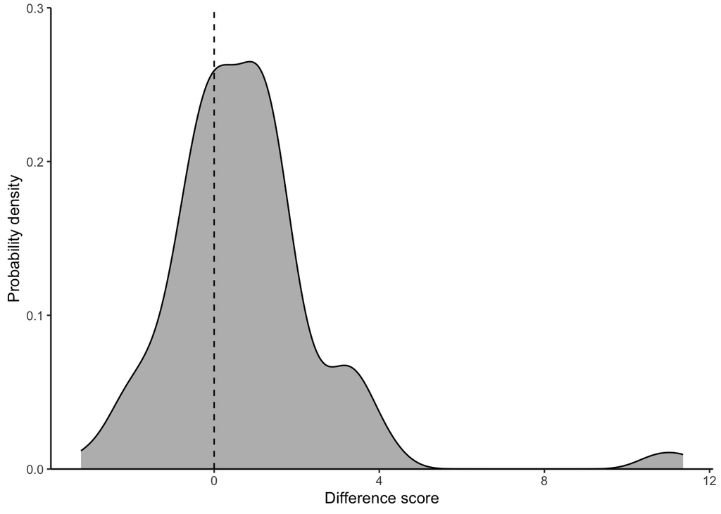

```r
# Plot basics:

diff_p <- df_ppt_wide |>
  ggplot(aes(x = diff)) +
  geom_density(fill = 'darkgrey', alpha = 0.8) +
  geom_vline(xintercept = 0, linetype = 'dashed')

# Axes and labels:

diff_p <- diff_p +
  scale_y_continuous(expand = c(0, 0),
                     limits = c(0, 0.3),
                     breaks = seq(0, 0.3, 0.1)) +
  xlab('Difference score') +
  ylab('Probability density')

# Cosmetics:

diff_p <- diff_p +
  theme_classic()

# Show and save:

diff_p
```

```r
ggsave(plot = diff_p,
       file = '../figures/difference_scores.pdf',
       width = 6, height = 4.5)
ggsave(plot = diff_p,
       file = '../figures/png/difference_scores.png',
       width = 6, height = 4.5)
```

## 7.2 Pair plot

Let’s create a pair plot to show the data, with lines connecting the inwards and outwards averages per participant. What we’ll then do is color the lines separately for whether they are congruent with our hypothesis (outwards = more) or incongruent. For this we need to merge the `effect` column from the `df_ppt_wide` data into the `df_ppt` data frame first.

```r
df_ppt <- left_join(df_ppt,
                    select(df_ppt_wide, id, effect))
```

For the plot we also want to provide annotations as to how many people have a congruent or incongruent effect, and that will be positioned to the right of the `outwards` category. So we should get the mean `outwards` magnitude across participants for the congruent and incongruent participants separately.

```r
annotate_y_positions <- df_ppt |>
  filter(movement == 'outwards') |>
  group_by(effect) |>
  summarize(M = mean(M)) |>
  pull(M)

# Extract percentages to be used for labels:

annotate_labels <- df_ppt_wide |>
  count(effect) |>
  mutate(prop = n / sum(n),
         prop = round(prop, 2),
         percentage = prop * 100,
         percentage = str_c(percentage, '%')) |>
  pull(percentage)
```

Now we can create the plot:

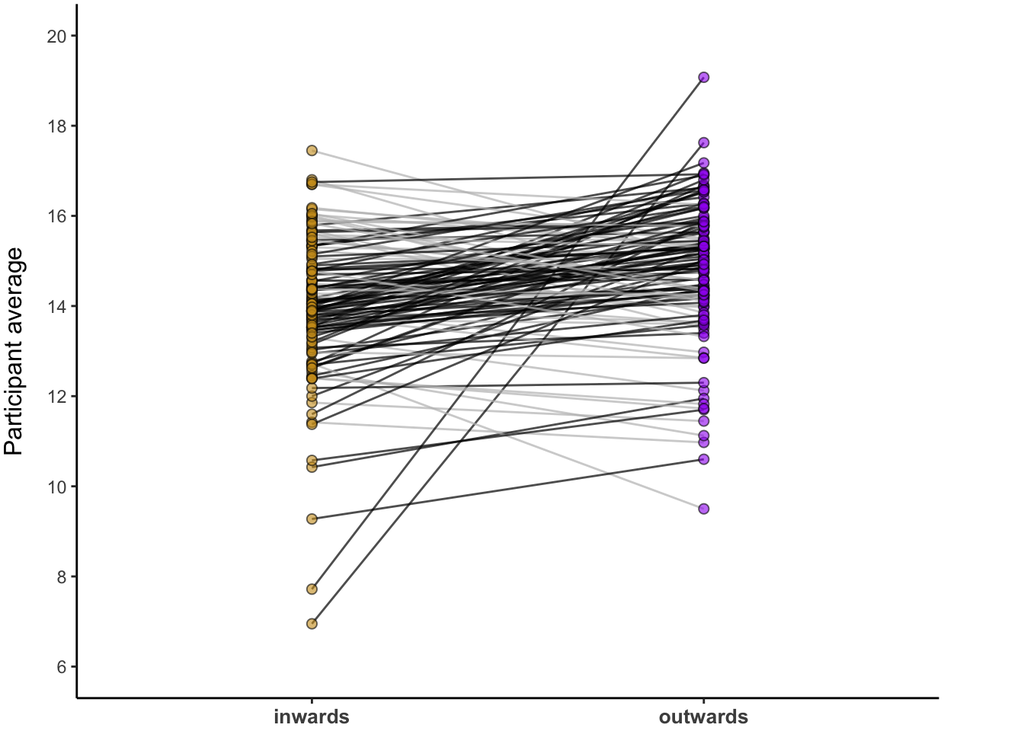

```r
# Plot basics:

pair_p <- df_ppt |>
  ggplot(aes(x = movement, y = M,
             group = id)) +
  geom_line(aes(col = effect), alpha = 0.7) +
  geom_point(aes(fill = movement), size = 2, alpha = 0.6,
             shape = 21, col = 'black')

# # Annotations:
#
# pair_p <- pair_p +
#   annotate('text',
#            x = rep(2.07, 2), y = annotate_y_positions,
#            label = str_c(annotate_labels,
#                          c(' of participants\n+sign',
#                            ' of participants\n-sign')),
#            col = c('black', 'grey'),
#            hjust = 0,
#            size = 3)

# Axes and labels:

pair_p <- pair_p +
  scale_color_manual(values = c('black', 'grey')) +
  scale_fill_manual(values = c('goldenrod3', 'purple')) +
  scale_y_continuous(limits = c(6, 20),
                     breaks = seq(6, 20, 2)) +
  xlab(NULL) +
  ylab('Participant average') +
  coord_cartesian(clip = 'off')

# Cosmetics:

pair_p <- pair_p +
  theme_classic() +
  theme(legend.position = 'none',
        axis.title.y = element_text(margin = margin(r = 10),
                                    size = 12),
        axis.text.x = element_text(face = 'bold', size = 10),
        plot.margin = margin(r = 42, t = 2, l = 2, b = 2))

# Show and save:

pair_p
```

```r
ggsave(plot = pair_p,
       file = '../figures/pair_plot.pdf',
       width = 3.5, height = 4.5)
ggsave(plot = pair_p,
       file = '../figures/png/pair_plot.png',
       width = 3.5, height = 4.5)
```

This looks pretty good. Those two participants with the *massive* effects are noteworthy, and we might want to do the analysis without that person to make sure that the effect is not driven by this obviously really influential point.

## 7.3 Extreme cases

Let’s try to find that participant and keep them in mind throughout the analysis below.

```r
filter(df_ppt_wide, diff > 6)
```

```
## # A tibble: 2 × 6
##   id          language inwards outwards  diff effect
##   <chr>       <chr>      <dbl>    <dbl> <dbl> <chr>
## 1 english_P19 english     6.95     17.6  10.7 congruent
## 2 english_P36 english     7.72     19.1  11.4 congruent
```

The two extreme cases are `english_P19` and `english_P36`. Store them in a vector to latter see how results are affected by excluding these two data points.

```r
extreme_cases <- filter(df_ppt_wide, diff > 6) |> pull(id)
```

# 8 Inferential statistics

## 8.1 Quick-and-dirty tests

Quick and dirty paired t-test on the by-participant averages, and a non-parametric equivalent just in case, although the data looks pretty normally distributed in the difference scores, which means this should actually be fine.

```r
# t-test, parametric:

t.test(filter(df_ppt, movement == 'inwards')$M,
       filter(df_ppt, movement == 'outwards')$M,
       paired = TRUE,
       var.equal = TRUE)
```

```
##
##  Paired t-test
##
## data:  filter(df_ppt, movement == "inwards")$M and filter(df_ppt, movement == "outwards")$M
## t = -4.2259, df = 119, p-value = 4.688e-05
## alternative hypothesis: true mean difference is not equal to 0
## 95 percent confidence interval:
##  -1.1189889 -0.4049384
## sample estimates:
## mean difference
##      -0.7619637
```

```r
# Wilcox test, non-parametric:

wilcox.test(filter(df_ppt, movement == 'inwards')$M,
            filter(df_ppt, movement == 'outwards')$M,
            paired = TRUE)
```

```
##
##  Wilcoxon signed rank test with continuity correction
##
## data:  filter(df_ppt, movement == "inwards")$M and filter(df_ppt, movement == "outwards")$M
## V = 1998.5, p-value = 1.942e-05
## alternative hypothesis: true location shift is not equal to 0
```

Effect size:

```r
cohen.d(M ~ movement,
        paired = TRUE,
        data = df_ppt)
```

```
##
## Cohen's d
##
## d estimate: -0.480579 (small)
## 95 percent confidence interval:
##      lower      upper
## -0.7171901 -0.2439679
```

Small effect, with Cohen’s d = 0.48.

What about when excluding those two extreme data points?

```r
# t-test, parametric:

t.test(filter(df_ppt, !id %in% extreme_cases, movement == 'inwards')$M,
       filter(df_ppt, !id %in% extreme_cases, movement == 'outwards')$M,
       paired = TRUE,
       var.equal = TRUE)
```

```
##
##  Paired t-test
##
## data:  filter(df_ppt, !id %in% extreme_cases, movement == "inwards")$M and filter(df_ppt, !id %in% extreme_cases, movement == "outwards")$M
## t = -4.3694, df = 117, p-value = 2.71e-05
## alternative hypothesis: true mean difference is not equal to 0
## 95 percent confidence interval:
##  -0.8547535 -0.3215785
## sample estimates:
## mean difference
##       -0.588166
```

```r
# Wilcox test, non-parametric:

wilcox.test(filter(df_ppt, !id %in% extreme_cases, movement == 'inwards')$M,
            filter(df_ppt, !id %in% extreme_cases, movement == 'outwards')$M,
            paired = TRUE)
```

```
##
##  Wilcoxon signed rank test with continuity correction
##
## data:  filter(df_ppt, !id %in% extreme_cases, movement == "inwards")$M and filter(df_ppt, !id %in% extreme_cases, movement == "outwards")$M
## V = 1998.5, p-value = 4.926e-05
## alternative hypothesis: true location shift is not equal to 0
```

Still significant.

A binomial test of just how many have positive sign is also significant.

```r
# Extract vector of congruent versus incongruent:

congruent_v_incongruent <- df_ppt_wide |> count(effect) |> pull(n)

# Test this:

binom.test(congruent_v_incongruent)
```

```
##
##  Exact binomial test
##
## data:  congruent_v_incongruent
## number of successes = 78, number of trials = 120, p-value = 0.001299
## alternative hypothesis: true probability of success is not equal to 0.5
## 95 percent confidence interval:
##  0.5576053 0.7347977
## sample estimates:
## probability of success
##                   0.65
```

Looks good too. While I don’t care much about significance tests, it’s nice to know that our results look strong when looked at from this very simple perspective that a lot of psych journals would consider to be good evidence.

## 8.2 Effect size sensitivity analysis

** NEW Nov 13, 2024 **: Reviewer 1 requested an effect size sensitivity analysis, as described in Giner-Sorolla et al. (2024), “Power to detect what?”

```r
pwr.t.test(n = 120, sig.level = 0.05, power = 0.8)
```

```
##
##      Two-sample t test power calculation
##
##               n = 120
##               d = 0.3631543
##       sig.level = 0.05
##           power = 0.8
##     alternative = two.sided
##
## NOTE: n is number in *each* group
```

To achieve 80% power with 120 participants, effect size would have to be at least d = 0.36, and we have d = 0.48

What if we had only half the sample size?

```r
pwr.t.test(n = 60, sig.level = 0.05, power = 0.8)
```

```
##
##      Two-sample t test power calculation
##
##               n = 60
##               d = 0.5157065
##       sig.level = 0.05
##           power = 0.8
##     alternative = two.sided
##
## NOTE: n is number in *each* group
```

Effect size would have to be d = 0.52.

A “post-hoc” power analysis (not so good) where we take the sample effect size (as we have no access to the population effect size) would suggest we have high power.

```r
pwr.t.test(n = 120, sig.level = 0.05, d = 0.48)
```

```
##
##      Two-sample t test power calculation
##
##               n = 120
##               d = 0.48
##       sig.level = 0.05
##           power = 0.9593381
##     alternative = two.sided
##
## NOTE: n is number in *each* group
```

power = 0.96

## 8.3 Main model

MCMC settings for better convergence (same for all models):

```r
mcmc_controls <- list(adapt_delta = 0.98,
                      max_treedepth = 13)
```

Set up mu/phi parametrization of beta-binomial (instead of hard-to-interpret a,b-parameterization) as a custom family. This code is from Alexandra Lorson:

```r
beta_binomial2 <- custom_family(
  "beta_binomial2", dpars = c("mu", "phi"),
  links = c("logit", "log"),
  lb = c(0, 2), ub = c(1, NA),
  type = "int", vars = "vint1[n]"
)

stan_funs <- "
  real beta_binomial2_lpmf(int y, real mu, real phi, int T) {
    return beta_binomial_lpmf(y | T, mu * phi, (1 - mu) * phi);
  }
  int beta_binomial2_rng(real mu, real phi, int T) {
    return beta_binomial_rng(T, mu * phi, (1 - mu) * phi);
  }
"

stanvars <- stanvar(scode = stan_funs, block = "functions")
```

Add set size to main tibble:

```r
df <- mutate(df, set_size = 30)
```

Build a model of the absolute differences:

```r
beta_mdl <- brm(number | vint(set_size) ~ 1 +
                  movement +
                  (1 + movement|id),

                # Params:

                data = df,
                family = beta_binomial2,
                stanvars = stanvars,

                # MCMC settings:

                cores = 4, init = 0, control = mcmc_controls,
                warmup = 3000, iter = 5000, chains = 4)

# Save:

save(beta_mdl,
     file = '../models/beta_mdl.RData')
```

Load the model for the markdown (the actual code chunks have been set to `eval = FALSE` as the models are precompiled).

```r
load('../models/beta_mdl.RData')
```

Check model:

```r
beta_mdl
```

[output not shown]

Test main hypothesis:

```r
hypothesis(beta_mdl, 'movementoutwards > 0')
```

```
## Hypothesis Tests for class b:
##               Hypothesis Estimate Est.Error CI.Lower CI.Upper Evid.Ratio
## 1 (movementoutwards) > 0      0.1      0.02     0.06     0.14        Inf
##   Post.Prob Star
## 1         1    *
## ---
## 'CI': 90%-CI for one-sided and 95%-CI for two-sided hypotheses.
## '*': For one-sided hypotheses, the posterior probability exceeds 95%;
## for two-sided hypotheses, the value tested against lies outside the 95%-CI.
## Posterior probabilities of point hypotheses assume equal prior probabilities.
```

Create the function for PP check:

```r
# posterior_predict_beta_binomial2 <- function(i, prep, ...) {
#   mu <- brms::get_dpar(prep, "mu", i = i)
#   phi <- brms::get_dpar(prep, "phi", i = i)
#   trials <- prep$data$vint1[i]
#   beta_binomial2_rng(mu, phi, trials)
# }
```

Check posterior predictive simulations:

```r
# pp_check(beta_mdl)
```

Extract the posterior of the condition difference for visualization:

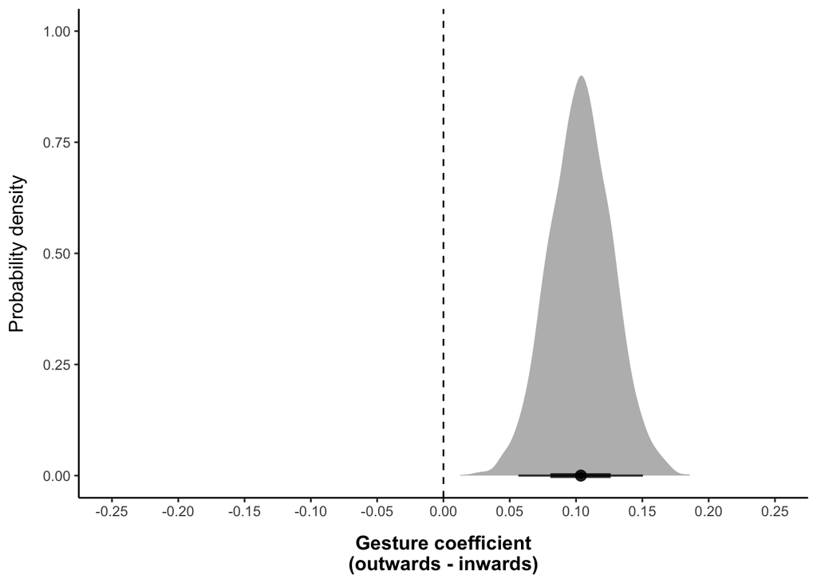

```r
# Plot basics:

diff_p <- as_draws_df(beta_mdl, variable = 'b_movementoutwards') |>
  ggplot(aes(x = b_movementoutwards)) +
  stat_halfeye(fill = 'darkgrey', alpha = 0.8) +
  geom_vline(xintercept = 0, linetype = 'dashed')

# Axes and labels:

diff_p <- diff_p +
  scale_x_continuous(limits = c(-0.25, 0.25),
                     breaks = seq(-0.25, 0.25, 0.05)) +
  scale_y_continuous(#expand = c(0, 0),
                     limits = c(0, 1),
                     breaks = seq(0, 1, 0.25)) +
  xlab('Gesture coefficient\n(outwards - inwards)') +
  ylab('Probability density')

# Cosmetics:

diff_p <- diff_p +
  theme_classic() +
  theme(axis.title.y = element_text(margin = margin(r = 10),
                                    size = 12),
        axis.title.x = element_text(face = 'bold', size = 12,
                                    margin = margin(t = 10)))

# Show and save:

diff_p
```

```r
ggsave(plot = diff_p,
       file = '../figures/main_mdl_posterior_effect.pdf',
       width = 6, height = 4.5)
ggsave(plot = diff_p,
       file = '../figures/png/main_mdl_posterior_effect.png',
       width = 6, height = 4.5)
```

As can be seen, the posterior is to the right of zero, which means that given this data and model, it is quite implausible that the gesture effect would go the other way around…

## 8.4 Individual CrIs from main model

** NEW Nov 13, 2024 **:

Reviewer 1 asked us to amend our 65% proportion of people show the effect, which is simply based on the sign of each participants average difference, with an approach that takes inferential uncertainty about each participant’s difference score into account. We welcome this suggestion and therefore extract the 95% CrI’s of each participant and check how many are above >0 using a 95% interval (analogous to “significance”), as well as using a 90% interval, as in Roth et al. (2024) “Don’t SNARC me now!”, Cognition.

```r
ppt_avgs <- coef(beta_mdl)[[1]][, , 'movementoutwards']
```

These are random effects deviations from the mean effect, so we also need to get the group average effect itself:

```r
avg_effect <- fixef(beta_mdl)['movementoutwards', 'Estimate']
```

Use this:

```r
sum((ppt_avgs[, 3] + avg_effect) > 0) / nrow(ppt_avgs)
```

```
## [1] 0.9583333
```

96% “significantly” above zero using a 95% interval.

Check variable names in posterior samples object so that we can use the `tidybayes` function `spread_draws()` to extract this:

```r
get_variables(beta_mdl)
```

```
##   [1] "b_Intercept"
##   [2] "b_movementoutwards"
##   [3] "sd_id__Intercept"
##   [4] "sd_id__movementoutwards"
##   [5] "cor_id__Intercept__movementoutwards"
##   [6] "phi"
##   [7] "r_id[english_P01,Intercept]"
##   [8] "r_id[english_P02,Intercept]"
##   [9] "r_id[english_P03,Intercept]"
##  [10] "r_id[english_P04,Intercept]"
##  [11] "r_id[english_P05,Intercept]"
##  [12] "r_id[english_P06,Intercept]"
##  [13] "r_id[english_P07,Intercept]"
##  [14] "r_id[english_P08,Intercept]"
##  [15] "r_id[english_P09,Intercept]"
```

[output cut: 239 more lines]

Extract posterior draws into a new object called `ind_posts` for individual posterior estimates:

```r
ind_posts <- beta_mdl |>
  spread_draws(r_id[id,movementoutwards]) |>
  filter(movementoutwards == 'movementoutwards') |>
  ungroup() |>
  select(-(.chain:.draw)) |>
  rename(posterior_sample = r_id)
```

Quickly sanity check the means:

```r
ind_posts |>
  group_by(id) |>
  summarize(M = mean(posterior_sample) + avg_effect) |>
  print(n = Inf)
```

```
## # A tibble: 120 × 2
##     id               M
##     <chr>        <dbl>
##   1 english_P01 0.0883
##   2 english_P02 0.0906
##   3 english_P03 0.134
##   4 english_P04 0.106
##   5 english_P05 0.106
##   6 english_P06 0.128
##   7 english_P07 0.113
##   8 english_P08 0.115
##   9 english_P09 0.0815
##  10 english_P10 0.107
##  11 english_P11 0.131
##  12 english_P12 0.0754
```

[output cut: 108 more lines]

```r
# How many of the means are above zero?

ind_posts |>
  group_by(id) |>
  summarize(M = mean(posterior_sample) + avg_effect) |>
  mutate(sign = if_else(M > 0, '+', '-')) |>
  count(sign)
```

```
## # A tibble: 1 × 2
##   sign      n
##   <chr> <int>
## 1 +       120
```

All… this is due to the presumably shrinkage towards the main effect. As we have many participants, shrinkage will be quite strong.

To be as analogous to Roth et al. (2024) as possible, let’s fit separate models for each participants. I’d usually never do that, but that way we don’t use any information from other participants to inform each participant’s estimate, i.e., each participant is regarded entirely on its own, unfettered by information from the group.

Chunk is set to `eval = FALSE` as it takes a long time.

```r
# Extract vector of participant ids:

all_ids <- df |> distinct(id) |> pull(id)

# Create empty table:

res <- tibble()

# Run individual models:

for (i in seq_along(all_ids)) {
  # Tell outside world where at:

  cat(str_c('Iteration: ', i, '; Fitting model for participant: ', all_ids[i], '\n\n'))

  # Extract subset that is only participant's data:

  this_df <- filter(df, id == all_ids[i])

  # Fit individual model to participant:

  this_mdl <- brm(number | vint(set_size) ~ 1 + movement,

                  # Params:

                  data = this_df,
                  family = beta_binomial2,
                  stanvars = stanvars,

                  # MCMC settings:

                  cores = 4, init = 0, control = mcmc_controls,
                  warmup = 3000, iter = 5000, chains = 4,

                  # MCMC settings for loop (suppress console output):

                  silent = 2, refresh = 0)

  # Table of results:

  ppt_df <- this_mdl |> spread_draws(b_movementoutwards) |>
    select(b_movementoutwards) |>
    mutate(id = all_ids[i])

  # Append individual to full data:

  res <- bind_rows(res, ppt_df)
}

# Save tibble:

write_csv(res, '../data/RNG_beta_mdl_individual_posteriors.csv')
```

Load the file since `EVAL = FALSE` above:

```r
ind_df <- read_csv('../data/RNG_beta_mdl_individual_posteriors.csv')
```

```r
ind_sum <- ind_df |>
  group_by(id) |>
  summarize(L_10 = quantile(b_movementoutwards, 0.1),
            U_90 = quantile(b_movementoutwards, 0.9)) |>
  mutate(significance = if_else(L_10 > 0, 'yes', 'not'))

# Check:

ind_sum
```

```
## # A tibble: 120 × 4
##    id             L_10   U_90 significance
##    <chr>         <dbl>  <dbl> <chr>
##  1 english_P01 -0.384  0.227  not
##  2 english_P02 -0.464  0.199  not
##  3 english_P03  0.247  0.898  yes
##  4 english_P04 -0.136  0.468  not
##  5 english_P05 -0.190  0.431  not
##  6 english_P06  0.131  0.799  yes
##  7 english_P07 -0.0997 0.546  not
##  8 english_P08 -0.0201 0.625  not
##  9 english_P09 -0.562  0.0691 not
## 10 english_P10 -0.223  0.431  not
## # ℹ 110 more rows
```

```r
ind_sum |>
  count(significance) |>
  mutate(p = n / sum(n))
```

```
## # A tibble: 2 × 3
##   significance     n     p
##   <chr>        <int> <dbl>
## 1 not            104 0.867
## 2 yes             16 0.133
```

Were there any ones that showed an effect that was “significantly” in the opposite direction?

```r
ind_sum <- ind_df |>
  group_by(id) |>
  summarize(L_10 = quantile(b_movementoutwards, 0.1),
            U_90 = quantile(b_movementoutwards, 0.9)) |>
  mutate(significance = if_else(U_90 < 0, 'yes', 'not'))

# Check:

ind_sum
```

```
## # A tibble: 120 × 4
##    id             L_10   U_90 significance
##    <chr>         <dbl>  <dbl> <chr>
##  1 english_P01 -0.384  0.227  not
##  2 english_P02 -0.464  0.199  not
##  3 english_P03  0.247  0.898  not
##  4 english_P04 -0.136  0.468  not
##  5 english_P05 -0.190  0.431  not
##  6 english_P06  0.131  0.799  not
##  7 english_P07 -0.0997 0.546  not
##  8 english_P08 -0.0201 0.625  not
##  9 english_P09 -0.562  0.0691 not
## 10 english_P10 -0.223  0.431  not
## # ℹ 110 more rows
```

```r
ind_sum |>
  count(significance) |>
  mutate(p = n / sum(n))
```

```
## # A tibble: 2 × 3
##   significance     n      p
##   <chr>        <int>  <dbl>
## 1 not            116 0.967
## 2 yes              4 0.0333
```

How many had a 90% interval that was more towards the right side though, in the direction of the effect?

```r
ind_sum |>
  mutate(U_vs_L = if_else(U_90 > L_10, 'right-leaning', 'left-leaning')) |>
  count(U_vs_L)
```

```
## # A tibble: 1 × 2
##   U_vs_L            n
##   <chr>         <int>
## 1 right-leaning   120
```

What is each participants probability of being above zero?

```r
prop_above_0 <- ind_df |>
  mutate(sign = if_else(b_movementoutwards >= 0, '+', '-')) |>
  count(id, sign) |>
  filter(sign == '+') |>
  mutate(prop = n / 8000)

# Check:

prop_above_0
```

```
## # A tibble: 120 × 4
##    id          sign      n  prop
##    <chr>       <chr> <int> <dbl>
##  1 english_P01 +      3007 0.376
##  2 english_P02 +      2432 0.304
##  3 english_P03 +      7910 0.989
##  4 english_P04 +      6047 0.756
##  5 english_P05 +      5511 0.689
##  6 english_P06 +      7684 0.960
##  7 english_P07 +      6474 0.809
##  8 english_P08 +      7065 0.883
##  9 english_P09 +      1250 0.156
## 10 english_P10 +      5256 0.657
## # ℹ 110 more rows
```

Now we can ask, for how many participants are we 50%/60%/70%/80%/90%/95% certain that they’re above zero?

```r
sum(prop_above_0$prop > 0.5) / nrow(prop_above_0)
```

```
## [1] 0.675
```

```r
sum(prop_above_0$prop > 0.8) / nrow(prop_above_0)
```

```
## [1] 0.2666667
```

```r
sum(prop_above_0$prop > 0.9) / nrow(prop_above_0)
```

```
## [1] 0.1333333
```

```r
sum(prop_above_0$prop > 0.95) / nrow(prop_above_0)
```

```
## [1] 0.1
```

For 27% of the sample we’re at least 80% certain it’s a positive effect. For 13% of the sample were 90% certain (matches above). For only 10% can we be certain that it is 95% consistent.

## 8.5 Language interaction

Build a model with the group effect. First, contrast code (sum-coding) both movement and language so that we can interpret the coefficients better later on:

```r
# Make into factor:

df <- mutate(df,
             movement_c = factor(movement, levels = c('outwards', 'inwards')),
             language_c = factor(language, levels = c('italian', 'english')))

# Sum-code:

contrasts(df$movement_c) <- contr.sum(2)
contrasts(df$language_c) <- contr.sum(2)

# Check:

contrasts(df$movement_c)
```

```
##          [,1]
## outwards    1
## inwards    -1
```

```r
contrasts(df$language_c)
```

```
##         [,1]
## italian    1
## english   -1
```

Now, run the model:

```r
beta_group_mdl <- brm(number | vint(set_size) ~ 1 +
                        movement_c +
                        language_c +
                        movement_c:language_c +
                        (1 + movement_c|id),

                      # Params:

                      data = df,
                      family = beta_binomial2,
                      stanvars = stanvars,

                      # MCMC settings:

                      cores = 4, init = 0, control = mcmc_controls,
                      warmup = 3000, iter = 5000, chains = 4)

# Save:

save(beta_group_mdl,
     file = '../models/beta_group_mdl.RData')
```

Load the model for the markdown (the actual code chunks have been set to `eval = FALSE` as the models are precompiled).

```r
load('../models/beta_group_mdl.RData')
```

Show:

```r
beta_group_mdl
```

```
##  Family: beta_binomial2
##   Links: mu = logit; phi = identity
## Formula: number | vint(set_size) ~ 1 + movement_c + language_c + movement_c:language_c + (1 + movement_c | id)
##    Data: df (Number of observations: 9580)
##   Draws: 4 chains, each with iter = 5000; warmup = 3000; thin = 1;
##          total post-warmup draws = 8000
##
## Multilevel Hyperparameters:
## ~id (Number of levels: 120)
##                            Estimate Est.Error l-95% CI u-95% CI Rhat Bulk_ESS
## sd(Intercept)                  0.07      0.02     0.02     0.11 1.00     1847
## sd(movement_c1)                0.04      0.02     0.00     0.08 1.00     1741
## cor(Intercept,movement_c1)    -0.07      0.50    -0.94     0.87 1.00     2990
##                            Tail_ESS
## sd(Intercept)                  1732
## sd(movement_c1)                3022
## cor(Intercept,movement_c1)     4047
##
## Regression Coefficients:
##                         Estimate Est.Error l-95% CI u-95% CI Rhat Bulk_ESS
## Intercept                  -0.03      0.01    -0.05     0.00 1.00     6639
## movement_c1                 0.05      0.01     0.03     0.08 1.00     8644
## language_c1                 0.05      0.01     0.02     0.07 1.00     7434
## movement_c1:language_c1    -0.00      0.01    -0.03     0.02 1.00     8846
##                         Tail_ESS
## Intercept                   5667
## movement_c1                 5704
## language_c1                 6100
## movement_c1:language_c1     5974
##
## Further Distributional Parameters:
##     Estimate Est.Error l-95% CI u-95% CI Rhat Bulk_ESS Tail_ESS
## phi     2.22      0.03     2.15     2.28 1.00     8906     4651
##
## Draws were sampled using sampling(NUTS). For each parameter, Bulk_ESS
## and Tail_ESS are effective sample size measures, and Rhat is the potential
## scale reduction factor on split chains (at convergence, Rhat = 1).
```

Hypothesis tests for movement, language, and movement * language interaction effect:

```r
hypothesis(beta_group_mdl, 'movement_c1 > 0')
```

```
## Hypothesis Tests for class b:
##          Hypothesis Estimate Est.Error CI.Lower CI.Upper Evid.Ratio Post.Prob
## 1 (movement_c1) > 0     0.05      0.01     0.03     0.07        Inf         1
##   Star
## 1    *
## ---
## 'CI': 90%-CI for one-sided and 95%-CI for two-sided hypotheses.
## '*': For one-sided hypotheses, the posterior probability exceeds 95%;
## for two-sided hypotheses, the value tested against lies outside the 95%-CI.
## Posterior probabilities of point hypotheses assume equal prior probabilities.
```

```r
hypothesis(beta_group_mdl, 'language_c1 > 0')
```

```
## Hypothesis Tests for class b:
##          Hypothesis Estimate Est.Error CI.Lower CI.Upper Evid.Ratio Post.Prob
## 1 (language_c1) > 0     0.05      0.01     0.02     0.07       3999         1
##   Star
## 1    *
## ---
## 'CI': 90%-CI for one-sided and 95%-CI for two-sided hypotheses.
## '*': For one-sided hypotheses, the posterior probability exceeds 95%;
## for two-sided hypotheses, the value tested against lies outside the 95%-CI.
## Posterior probabilities of point hypotheses assume equal prior probabilities.
```

```r
hypothesis(beta_group_mdl, 'movement_c1:language_c1 < 0')
```

```
## Hypothesis Tests for class b:
##                 Hypothesis Estimate Est.Error CI.Lower CI.Upper Evid.Ratio
## 1 (movement_c1:lang... < 0        0      0.01    -0.02     0.02       1.31
##   Post.Prob Star
## 1      0.57
## ---
## 'CI': 90%-CI for one-sided and 95%-CI for two-sided hypotheses.
## '*': For one-sided hypotheses, the posterior probability exceeds 95%;
## for two-sided hypotheses, the value tested against lies outside the 95%-CI.
## Posterior probabilities of point hypotheses assume equal prior probabilities.
```

Absolutely no interaction. The language effect is unexpected! Let’s see how much larger our expected gesture effect is:

```r
hypothesis(beta_group_mdl, 'movement_c1 > language_c1')
```

```
## Hypothesis Tests for class b:
##                 Hypothesis Estimate Est.Error CI.Lower CI.Upper Evid.Ratio
## 1 (movement_c1)-(la... > 0     0.01      0.02    -0.02     0.04       1.78
##   Post.Prob Star
## 1      0.64
## ---
## 'CI': 90%-CI for one-sided and 95%-CI for two-sided hypotheses.
## '*': For one-sided hypotheses, the posterior probability exceeds 95%;
## for two-sided hypotheses, the value tested against lies outside the 95%-CI.
## Posterior probabilities of point hypotheses assume equal prior probabilities.
```

```r
# Show coefficient table:

fixef(beta_group_mdl)
```

```
##                             Estimate  Est.Error        Q2.5        Q97.5
## Intercept               -0.025728239 0.01310714 -0.05187997 7.728167e-05
## movement_c1              0.051960593 0.01222437  0.02807053 7.624397e-02
## language_c1              0.045320408 0.01319792  0.01953677 7.148070e-02
## movement_c1:language_c1 -0.001839574 0.01206017 -0.02553824 2.202249e-02
```

```r
# Compare movement effect (2nd row) against language (3rd):

fixef(beta_group_mdl)[2, 1] / fixef(beta_group_mdl)[3, 1]
```

```
## [1] 1.146516
```

The gesture effect is 1.15 as large as the language effect.

Get all the posterior values for the three fixed effects coefficients:

```r
group_posts <- as_draws_df(beta_group_mdl) |>
  select(b_movement_c1:`b_movement_c1:language_c1`) |>
  pivot_longer(b_movement_c1:`b_movement_c1:language_c1`,
               values_to = 'estimate',
               names_to = 'coefficient') |>
  mutate(coefficient = if_else(coefficient == 'b_movement_c1',
                               'gesture effect', coefficient),
         coefficient = if_else(coefficient == 'b_language_c1',
                               'language effect', coefficient),
         coefficient = if_else(coefficient == 'b_movement_c1:language_c1',
                               'gesture * language interaction', coefficient))
# Show:

group_posts
```

```
## # A tibble: 24,000 × 2
##    coefficient                    estimate
##    <chr>                             <dbl>
##  1 gesture effect                  0.0419
##  2 language effect                 0.0544
##  3 gesture * language interaction -0.00853
##  4 gesture effect                  0.0346
##  5 language effect                 0.0627
##  6 gesture * language interaction  0.00279
##  7 gesture effect                  0.0483
##  8 language effect                 0.0498
##  9 gesture * language interaction -0.0151
## 10 gesture effect                  0.0507
## # ℹ 23,990 more rows
```

Create a density plot of the three fixed effects.

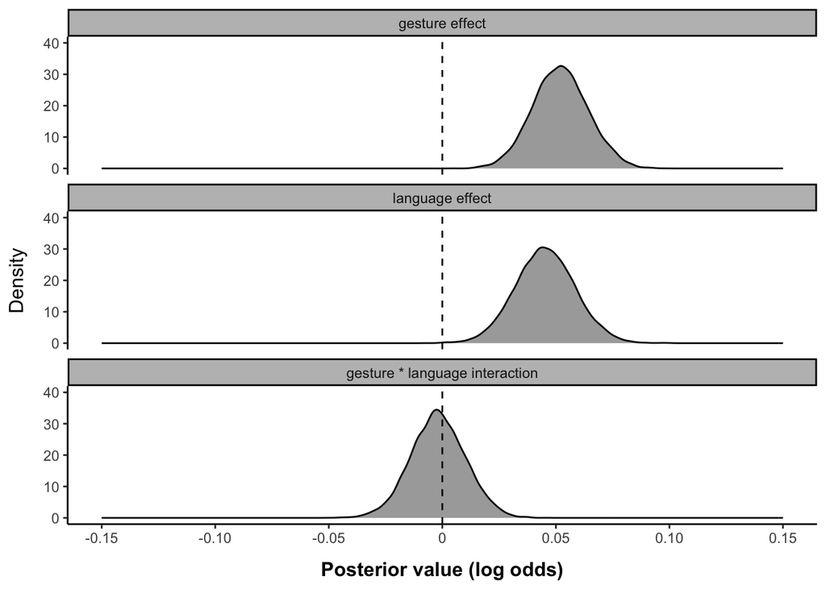

```r
# Order of levels:

fac_order <- c('gesture effect', 'language effect',
               'gesture * language interaction')

# Plot basics:

diff_p <- group_posts |>
  mutate(coefficient = factor(coefficient, levels = fac_order)) |>
  ggplot(aes(x = estimate)) +
  facet_wrap(~coefficient, nrow = 3) +
  geom_density(fill = 'darkgrey')

# Axes and labels:

diff_p <- diff_p +
  geom_vline(xintercept = 0, linetype = 'dashed') +
  scale_x_continuous(limits = c(-0.15, 0.15),
                     breaks = seq(-0.15, 0.15, 0.05),
                     labels = c("-0.15", "-0.10", "-0.05", "0",
                                "0.05", "0.10", "0.15")) +
  scale_y_continuous(limits = c(0, 40),
                     breaks = seq(0, 40, 10)) +
  xlab('Posterior value (log odds)') +
  ylab('Density')

# Cosmetics:

diff_p <- diff_p +
  theme_classic() +
  theme(axis.title.y = element_text(margin = margin(r = 10),
                                    size = 12),
        axis.title.x = element_text(face = 'bold', size = 12,
                                    margin = margin(t = 10)),
        strip.background = element_rect(fill = 'grey'))

# Show and save:

diff_p
```

```r
ggsave(plot = diff_p,
       file = '../figures/group_mdl_posterior_effect.pdf',
       width = 4, height = 6.5)
ggsave(plot = diff_p,
       file = '../figures/png/group_mdl_posterior_effect.png',
       width = 4, height = 6.5)
```

## 8.6 Starting position

Build a model with starting position as well.

As we’re interested in the interaction, it would make sense to sum code the binary terms nested in the interaction. We already got `movement_c` from the above, and all that’s needed is `start_c`:

```r
# Make into factor:

df <- mutate(df,
             start_c = factor(start_position, levels = c('outwards', 'inwards')))

# Sum-code:

contrasts(df$start_c) <- contr.sum(2)

# Check:

contrasts(df$start_c)
```

```
##          [,1]
## outwards    1
## inwards    -1
```

Now we can run the model:

```r
start_mdl <- brm(number | vint(set_size) ~ 1 +
                   movement_c + start_c +
                   movement_c:start_c +
                   (1 + movement_c|id),

                 # Params:

                 data = df,
                 family = beta_binomial2,
                 stanvars = stanvars,

                 # MCMC settings:

                 cores = 4, init = 0, control = mcmc_controls,
                 warmup = 3000, iter = 5000, chains = 4)

# Save:

save(start_mdl,
     file = '../models/start_mdl.RData')
```

Load the model for the markdown (the actual code chunks have been set to `eval = FALSE` as the models are precompiled).

```r
load('../models/start_mdl.RData')
```

Check model:

```r
start_mdl
```

```
##  Family: beta_binomial2
##   Links: mu = logit; phi = identity
## Formula: number | vint(set_size) ~ 1 + movement_c + start_c + movement_c:start_c + (1 + movement_c | id)
##    Data: df (Number of observations: 9580)
##   Draws: 4 chains, each with iter = 5000; warmup = 3000; thin = 1;
##          total post-warmup draws = 8000
##
## Multilevel Hyperparameters:
## ~id (Number of levels: 120)
##                            Estimate Est.Error l-95% CI u-95% CI Rhat Bulk_ESS
## sd(Intercept)                  0.08      0.02     0.04     0.12 1.00     2226
## sd(movement_c1)                0.03      0.02     0.00     0.08 1.01     1658
## cor(Intercept,movement_c1)    -0.05      0.49    -0.92     0.89 1.00     3779
##                            Tail_ESS
## sd(Intercept)                  1734
## sd(movement_c1)                2837
## cor(Intercept,movement_c1)     3834
##
## Regression Coefficients:
##                      Estimate Est.Error l-95% CI u-95% CI Rhat Bulk_ESS
## Intercept               -0.03      0.01    -0.05     0.00 1.00     6456
## movement_c1              0.05      0.01     0.03     0.08 1.00     9843
## start_c1                 0.03      0.01    -0.00     0.05 1.00     7061
## movement_c1:start_c1    -0.01      0.01    -0.03     0.02 1.00    10732
##                      Tail_ESS
## Intercept                5644
## movement_c1              6199
## start_c1                 6243
## movement_c1:start_c1     5902
##
## Further Distributional Parameters:
##     Estimate Est.Error l-95% CI u-95% CI Rhat Bulk_ESS Tail_ESS
## phi     2.22      0.03     2.16     2.28 1.00    10867     5569
##
## Draws were sampled using sampling(NUTS). For each parameter, Bulk_ESS
## and Tail_ESS are effective sample size measures, and Rhat is the potential
## scale reduction factor on split chains (at convergence, Rhat = 1).
```

Test main hypothesis:

```r
hypothesis(start_mdl, 'movement_c1 > 0')
```

```
## Hypothesis Tests for class b:
##          Hypothesis Estimate Est.Error CI.Lower CI.Upper Evid.Ratio Post.Prob
## 1 (movement_c1) > 0     0.05      0.01     0.03     0.07        Inf         1
##   Star
## 1    *
## ---
## 'CI': 90%-CI for one-sided and 95%-CI for two-sided hypotheses.
## '*': For one-sided hypotheses, the posterior probability exceeds 95%;
## for two-sided hypotheses, the value tested against lies outside the 95%-CI.
## Posterior probabilities of point hypotheses assume equal prior probabilities.
```

```r
hypothesis(start_mdl, 'start_c1 > 0')
```

```
## Hypothesis Tests for class b:
##       Hypothesis Estimate Est.Error CI.Lower CI.Upper Evid.Ratio Post.Prob Star
## 1 (start_c1) > 0     0.03      0.01        0     0.05      30.37      0.97    *
## ---
## 'CI': 90%-CI for one-sided and 95%-CI for two-sided hypotheses.
## '*': For one-sided hypotheses, the posterior probability exceeds 95%;
## for two-sided hypotheses, the value tested against lies outside the 95%-CI.
## Posterior probabilities of point hypotheses assume equal prior probabilities.
```

```r
hypothesis(start_mdl, 'movement_c1:start_c1 < 0')
```

```
## Hypothesis Tests for class b:
##                 Hypothesis Estimate Est.Error CI.Lower CI.Upper Evid.Ratio
## 1 (movement_c1:star... < 0    -0.01      0.01    -0.03     0.01       2.23
##   Post.Prob Star
## 1      0.69
## ---
## 'CI': 90%-CI for one-sided and 95%-CI for two-sided hypotheses.
## '*': For one-sided hypotheses, the posterior probability exceeds 95%;
## for two-sided hypotheses, the value tested against lies outside the 95%-CI.
## Posterior probabilities of point hypotheses assume equal prior probabilities.
```

Descriptive statistics:

```r
df |>
  group_by(start_position) |>
  summarize(M = mean(number, na.rm = TRUE))
```

```
## # A tibble: 2 × 2
##   start_position     M
##   <chr>          <dbl>
## 1 inwards         14.2
## 2 outwards        14.6
```

## 8.7 Gender

Check whether this is affected by gender. For this, let’s sum-code gender:

```r
df <- mutate(df,
             gender_c = factor(gender, levels = c('male', 'female')))

# Sum-code:

contrasts(df$gender_c) <- contr.sum(2)

# Check:

contrasts(df$gender_c)
```

```
##        [,1]
## male      1
## female   -1
```

Correct, with female as “reference level”.

```r
gender_mdl <- brm(number | vint(set_size) ~ 1 +
                    movement_c + gender_c +
                    movement_c:gender_c +
                    (1 + movement_c|id),

                # Params:

                data = df,
                family = beta_binomial2,
                stanvars = stanvars,

                # MCMC settings:

                cores = 4, init = 0, control = mcmc_controls,
                warmup = 3000, iter = 5000, chains = 4)

# Save:

save(gender_mdl,
     file = '../models/gender_mdl.RData')
```

Load the model for the markdown (the actual code chunks have been set to `eval = FALSE` as the models are precompiled).

```r
load('../models/gender_mdl.RData')
```

Check model:

```r
gender_mdl
```

```
##  Family: beta_binomial2
##   Links: mu = logit; phi = identity
## Formula: number | vint(set_size) ~ 1 + movement_c + gender_c + movement_c:gender_c + (1 + movement_c | id)
##    Data: df (Number of observations: 9580)
##   Draws: 4 chains, each with iter = 5000; warmup = 3000; thin = 1;
##          total post-warmup draws = 8000
##
## Multilevel Hyperparameters:
## ~id (Number of levels: 120)
##                            Estimate Est.Error l-95% CI u-95% CI Rhat Bulk_ESS
## sd(Intercept)                  0.08      0.02     0.04     0.12 1.00     2493
## sd(movement_c1)                0.03      0.02     0.00     0.08 1.00     1639
## cor(Intercept,movement_c1)    -0.08      0.49    -0.93     0.88 1.00     3964
##                            Tail_ESS
## sd(Intercept)                  1969
## sd(movement_c1)                3264
## cor(Intercept,movement_c1)     4074
##
## Regression Coefficients:
##                       Estimate Est.Error l-95% CI u-95% CI Rhat Bulk_ESS
## Intercept                -0.02      0.02    -0.06     0.01 1.00     6164
## movement_c1               0.06      0.01     0.03     0.09 1.00     7286
## gender_c1                 0.00      0.02    -0.03     0.03 1.00     6582
## movement_c1:gender_c1     0.01      0.01    -0.01     0.04 1.00     7191
##                       Tail_ESS
## Intercept                 5640
## movement_c1               5351
## gender_c1                 5882
## movement_c1:gender_c1     6456
##
## Further Distributional Parameters:
##     Estimate Est.Error l-95% CI u-95% CI Rhat Bulk_ESS Tail_ESS
## phi     2.22      0.03     2.15     2.29 1.00     9708     4964
##
## Draws were sampled using sampling(NUTS). For each parameter, Bulk_ESS
## and Tail_ESS are effective sample size measures, and Rhat is the potential
## scale reduction factor on split chains (at convergence, Rhat = 1).
```

Test main hypothesis:

```r
hypothesis(gender_mdl, 'movement_c1 > 0')
```

```
## Hypothesis Tests for class b:
##          Hypothesis Estimate Est.Error CI.Lower CI.Upper Evid.Ratio Post.Prob
## 1 (movement_c1) > 0     0.06      0.01     0.04     0.08        Inf         1
##   Star
## 1    *
## ---
## 'CI': 90%-CI for one-sided and 95%-CI for two-sided hypotheses.
## '*': For one-sided hypotheses, the posterior probability exceeds 95%;
## for two-sided hypotheses, the value tested against lies outside the 95%-CI.
## Posterior probabilities of point hypotheses assume equal prior probabilities.
```

```r
hypothesis(gender_mdl, 'gender_c1 > 0') # nothing
```

```
## Hypothesis Tests for class b:
##        Hypothesis Estimate Est.Error CI.Lower CI.Upper Evid.Ratio Post.Prob
## 1 (gender_c1) > 0        0      0.02    -0.03     0.03       1.07      0.52
##   Star
## 1
## ---
## 'CI': 90%-CI for one-sided and 95%-CI for two-sided hypotheses.
## '*': For one-sided hypotheses, the posterior probability exceeds 95%;
## for two-sided hypotheses, the value tested against lies outside the 95%-CI.
## Posterior probabilities of point hypotheses assume equal prior probabilities.
```

```r
hypothesis(gender_mdl, 'movement_c1:gender_c1 > 0')
```

```
## Hypothesis Tests for class b:
##                 Hypothesis Estimate Est.Error CI.Lower CI.Upper Evid.Ratio
## 1 (movement_c1:gend... > 0     0.01      0.01    -0.01     0.04       5.14
##   Post.Prob Star
## 1      0.84
## ---
## 'CI': 90%-CI for one-sided and 95%-CI for two-sided hypotheses.
## '*': For one-sided hypotheses, the posterior probability exceeds 95%;
## for two-sided hypotheses, the value tested against lies outside the 95%-CI.
## Posterior probabilities of point hypotheses assume equal prior probabilities.
```

84% certain that men have a larger number on outwards gestures. Not sufficient evidence however.

# 9 Individual differences

## 9.1 Distribution of BAG and SNS

We’ll look at BAG and SNS in relation to magnitude difference between conditions. Let’s use the already extant `df_ppt_wide` from above for this, since we have the difference scores already in there. We just need to re-append the `BAG` and `SNS` data.

```r
df_ppt_wide <- left_join(df_ppt_wide,
                         distinct(select(df, id, BAG, SNS)))
```

Have a look at the distribution of the BAG scale:

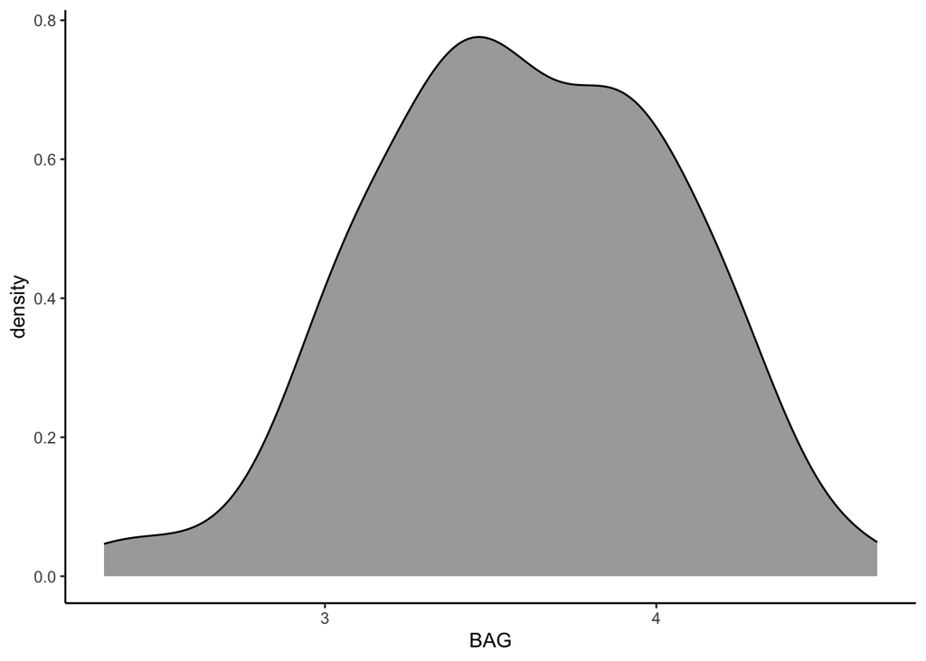

```r
df_ppt_wide |>
  ggplot(aes(x = BAG)) +
  geom_density(fill = 'darkgrey') +
  theme_classic()
```

Nothing too noteworthy.

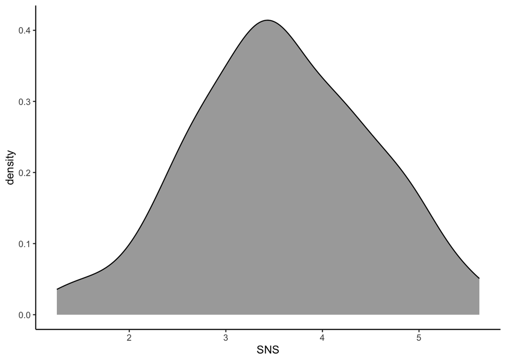

```r
df_ppt_wide |>
  ggplot(aes(x = SNS)) +
  geom_density(fill = 'darkgrey') +
  theme_classic()
```

Similarly unremarkable.

Let’s also look at whether the BAG or SNS scales are different for English and Italian.

```r
# Gesture scale:

df_ppt_wide |>
  group_by(language) |>
  summarize(M = mean(BAG),
            sd = sd(BAG))
```

```
## # A tibble: 2 × 3
##   language     M    sd
##   <chr>    <dbl> <dbl>
## 1 english   3.65 0.439
## 2 italian   3.55 0.464
```

```r
# Numeracy scale:

df_ppt_wide |>
  group_by(language) |>
  summarize(M = mean(SNS),
            sd = sd(SNS))
```

```
## # A tibble: 2 × 3
##   language     M    sd
##   <chr>    <dbl> <dbl>
## 1 english   3.53 1.03
## 2 italian   3.62 0.837
```

No big differences.

Are `BAG` and `SNS` correlated?

```r
with(df_ppt_wide, cor.test(BAG, SNS, method = 'pearson'))
```

```
##
##  Pearson's product-moment correlation
##
## data:  BAG and SNS
## t = -2.4653, df = 118, p-value = 0.01513
## alternative hypothesis: true correlation is not equal to 0
## 95 percent confidence interval:
##  -0.38528230 -0.04382248
## sample estimates:
##        cor
## -0.2213254
```

```r
with(df_ppt_wide, cor.test(BAG, SNS, method = 'spearman'))
```

```
##
##  Spearman's rank correlation rho
##
## data:  BAG and SNS
## S = 348235, p-value = 0.02182
## alternative hypothesis: true rho is not equal to 0
## sample estimates:
##       rho
## -0.209234
```

They are weakly negatively correlated. People who gesture more self-report to have less numeracy. But let’s not get too excited about this, it’s a weak correlation!

## 9.2 Simple correlations

Perform correlations:

```r
# Difference score with BAG:

with(df_ppt_wide,
     cor.test(diff, BAG, method = 'pearson'))
```

```
##
##  Pearson's product-moment correlation
##
## data:  diff and BAG
## t = 1.4702, df = 118, p-value = 0.1442
## alternative hypothesis: true correlation is not equal to 0
## 95 percent confidence interval:
##  -0.04622985  0.30600767
## sample estimates:
##       cor
## 0.1341229
```

```r
with(df_ppt_wide,
     cor.test(diff, BAG, method = 'spearman'))
```

```
##
##  Spearman's rank correlation rho
##
## data:  diff and BAG
## S = 260607, p-value = 0.3018
## alternative hypothesis: true rho is not equal to 0
## sample estimates:
##        rho
## 0.09505023
```

```r
# Difference score with SNS:

with(df_ppt_wide,
     cor.test(diff, SNS, method = 'pearson'))
```

```
##
##  Pearson's product-moment correlation
##
## data:  diff and SNS
## t = -1.3447, df = 118, p-value = 0.1813
## alternative hypothesis: true correlation is not equal to 0
## 95 percent confidence interval:
##  -0.29558254  0.05766116
## sample estimates:
##        cor
## -0.1228499
```

```r
with(df_ppt_wide,
     cor.test(diff, SNS, method = 'spearman'))
```

```
##
##  Spearman's rank correlation rho
##
## data:  diff and SNS
## S = 338369, p-value = 0.05594
## alternative hypothesis: true rho is not equal to 0
## sample estimates:
##        rho
## -0.1749752
```

All correlations are really small in size.

Let’s explore to what extent they are driven by the extreme cases, the two participants with really large effects:

```r
# Difference score with BAG:

with(filter(df_ppt_wide, !id %in% extreme_cases),
     cor.test(diff, BAG, method = 'pearson'))
```

```
##
##  Pearson's product-moment correlation
##
## data:  diff and BAG
## t = 0.71058, df = 116, p-value = 0.4788
## alternative hypothesis: true correlation is not equal to 0
## 95 percent confidence interval:
##  -0.1163108  0.2436921
## sample estimates:
##        cor
## 0.06583269
```

```r
with(filter(df_ppt_wide, !id %in% extreme_cases),
     cor.test(diff, BAG, method = 'spearman'))
```

```
##
##  Spearman's rank correlation rho
##
## data:  diff and BAG
## S = 255674, p-value = 0.4759
## alternative hypothesis: true rho is not equal to 0
## sample estimates:
##        rho
## 0.06626702
```

```r
# Difference score with SNS:

with(filter(df_ppt_wide, !id %in% extreme_cases),
     cor.test(diff, SNS, method = 'pearson'))
```

```
##
##  Pearson's product-moment correlation
##
## data:  diff and SNS
## t = -1.6485, df = 116, p-value = 0.102
## alternative hypothesis: true correlation is not equal to 0
## 95 percent confidence interval:
##  -0.32321764  0.03028995
## sample estimates:
##        cor
## -0.1512978
```

```r
with(filter(df_ppt_wide, !id %in% extreme_cases),
     cor.test(diff, SNS, method = 'spearman'))
```

```
##
##  Spearman's rank correlation rho
##
## data:  diff and SNS
## S = 321784, p-value = 0.05779
## alternative hypothesis: true rho is not equal to 0
## sample estimates:
##       rho
## -0.175169
```

## 9.3 Scatterplots

Make a scatter plot for BAG scale:

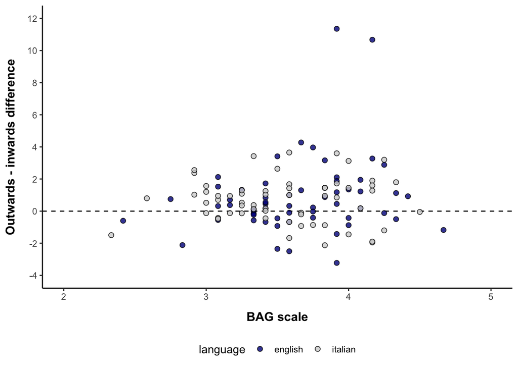

```r
# Plot basics:

BAG_p <- df_ppt_wide |>
  ggplot(aes(x = BAG, y = diff)) +
  geom_hline(yintercept = 0, linetype = 'dashed') +
  geom_point(aes(fill = language),
             alpha = 0.8,
             shape = 21,
             col = 'black',
             size = 2)

# Axes and scales:

BAG_p <- BAG_p +
  scale_x_continuous(limits = c(2, 5),
                     breaks = 2:5) +
  scale_y_continuous(limits = c(-4, 12),
                     breaks = seq(-4, 12, 2)) +
  scale_fill_manual(values = c('darkblue', 'lightgrey')) +
  xlab('BAG scale') +
  ylab('Outwards - inwards difference')

# Cosmetics:

BAG_p <- BAG_p +
  theme_classic() +
  theme(axis.title.y = element_text(face = 'bold', size = 12,
                                    margin = margin(r = 10)),
        axis.title.x = element_text(face = 'bold', size = 12,
                                    margin = margin(t = 10)),
        legend.position = 'bottom')

# Show and save:

BAG_p
```

```r
ggsave(plot = BAG_p,
       file = '../figures/BAG_scatterplot.pdf',
       width = 5.4, height = 4.5)
ggsave(plot = BAG_p,
       file = '../figures/png/BAG_scatterplot.png',
       width = 5.4, height = 4.5)
```

Make a scatter plot for SNS scale:

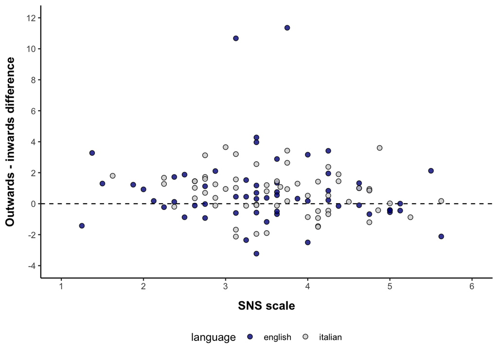

```r
# Plot basics:

SNS_p <- df_ppt_wide |>
  ggplot(aes(x = SNS, y = diff)) +
  geom_hline(yintercept = 0, linetype = 'dashed') +
  geom_point(aes(fill = language),
             alpha = 0.8,
             shape = 21,
             col = 'black',
             size = 2)

# Axes and scales:

SNS_p <- SNS_p +
  scale_x_continuous(limits = c(1, 6),
                     breaks = 1:6) +
  scale_y_continuous(limits = c(-4, 12),
                     breaks = seq(-4, 12, 2)) +
  scale_fill_manual(values = c('darkblue', 'lightgrey')) +
  xlab('SNS scale') +
  ylab('Outwards - inwards difference')

# Cosmetics:

SNS_p <- SNS_p +
  theme_classic() +
  theme(axis.title.y = element_text(face = 'bold', size = 12,
                                    margin = margin(r = 10)),
        axis.title.x = element_text(face = 'bold', size = 12,
                                    margin = margin(t = 10)),
        legend.position = 'bottom')

# Show and save:

SNS_p
```

```r
ggsave(plot = SNS_p,
       file = '../figures/SNS_scatterplot.pdf',
       width = 5.4, height = 4.5)
ggsave(plot = SNS_p,
       file = '../figures/png/SNS_scatterplot.png',
       width = 5.4, height = 4.5)
```

Put both together into a double plot with `patchwork`. For the second plot, we don’t need to repeat the y-axis, so we can switch that off. And we can get rid of the legend for that as well and change the legend position for the BAG plot.

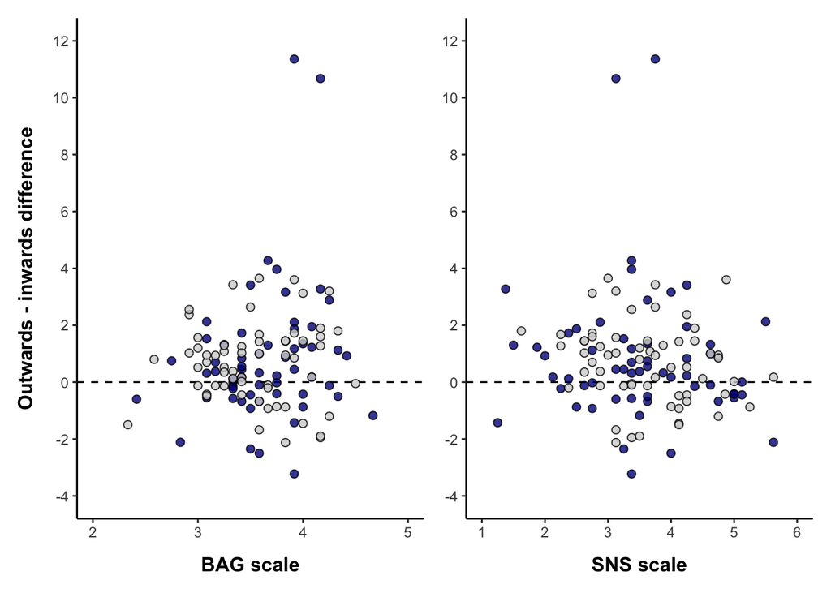

```r
# Changes to plot for double plot:

BAG_p <- BAG_p +
  theme(legend.position = 'none')
SNS_p <- SNS_p +
  ylab(NULL) +
  theme(legend.position = 'none')

# Patch together:

double_p <- BAG_p + SNS_p

# Show and save:

double_p
```

```r
ggsave(plot = double_p,
       file = '../figures/double_plot.pdf',
       width = 8, height = 3.5)
ggsave(plot = double_p,
       file = '../figures/png/double_plot.png',
       width = 8, height = 3.5)
```

## 9.4 Model with BAG interaction

To test for the interaction of `BAG` and `SNS`, let’s center them for more interpretable regression coefficients.

```r
df <- mutate(df,
             BAG_c = BAG - mean(BAG, na.rm = TRUE),
             BAG_c = BAG_c / sd(BAG_c),

             SNS_c = SNS - mean(SNS, na.rm = TRUE),
             SNS_c = SNS_c / sd(SNS_c))

# Check:

df
```

```
## # A tibble: 9,817 × 18
##    id          gender   age handedness trial movement   SNS   BAG number
##    <chr>       <chr>  <dbl> <chr>      <dbl> <chr>    <dbl> <dbl>  <dbl>
##  1 italian_P01 female    23 right          1 outwards  3.38  4.17      1
##  2 italian_P01 female    23 right          2 inwards   3.38  4.17      5
##  3 italian_P01 female    23 right          3 outwards  3.38  4.17      7
##  4 italian_P01 female    23 right          4 inwards   3.38  4.17     12
##  5 italian_P01 female    23 right          5 outwards  3.38  4.17      3
##  6 italian_P01 female    23 right          6 inwards   3.38  4.17     21
##  7 italian_P01 female    23 right          7 outwards  3.38  4.17     30
##  8 italian_P01 female    23 right          8 inwards   3.38  4.17     27
##  9 italian_P01 female    23 right          9 outwards  3.38  4.17     18
## 10 italian_P01 female    23 right         10 inwards   3.38  4.17     13
## # ℹ 9,807 more rows
## # ℹ 9 more variables: start_position <chr>, language <chr>, set_size <dbl>,
## #   movement_c <fct>, language_c <fct>, start_c <fct>, gender_c <fct>,
## #   BAG_c <dbl>, SNS_c <dbl>
```

Looks good. Now the model with the interaction. We’ll leave `movement` treatment coded as that’s easily interpretable anyway given it’s only two levels.

Now, run the model:

```r
BAG_mdl <- brm(number | vint(set_size) ~ 1 +
                 movement + BAG_c +
                 movement:BAG_c +
                 (1 + movement_c|id),
                data = df,
                family = beta_binomial2,
                stanvars = stanvars,

                # MCMC settings:

                cores = 4, init = 0, control = mcmc_controls,
                warmup = 3000, iter = 5000, chains = 4)

# Save:

save(BAG_mdl,
     file = '../models/BAG_mdl.RData')
```

Load the model for the markdown (the actual code chunks have been set to `eval = FALSE` as the models are precompiled).

```r
load('../models/BAG_mdl.RData')
```

Show:

```r
BAG_mdl
```

```
##  Family: beta_binomial2
##   Links: mu = logit; phi = identity
## Formula: number | vint(set_size) ~ 1 + movement + BAG_c + movement:BAG_c + (1 + movement_c | id)
##    Data: df (Number of observations: 9580)
##   Draws: 4 chains, each with iter = 5000; warmup = 3000; thin = 1;
##          total post-warmup draws = 8000
##
## Multilevel Hyperparameters:
## ~id (Number of levels: 120)
##                            Estimate Est.Error l-95% CI u-95% CI Rhat Bulk_ESS
## sd(Intercept)                  0.08      0.02     0.04     0.12 1.00     2353
## sd(movement_c1)                0.03      0.02     0.00     0.08 1.00     1663
## cor(Intercept,movement_c1)    -0.08      0.50    -0.94     0.88 1.00     4101
##                            Tail_ESS
## sd(Intercept)                  2531
## sd(movement_c1)                3125
## cor(Intercept,movement_c1)     4090
##
## Regression Coefficients:
##                        Estimate Est.Error l-95% CI u-95% CI Rhat Bulk_ESS
## Intercept                 -0.08      0.02    -0.11    -0.04 1.00     7375
## movementoutwards           0.10      0.02     0.06     0.15 1.00     8816
## BAG_c                     -0.02      0.02    -0.06     0.01 1.00     5244
## movementoutwards:BAG_c     0.04      0.03    -0.01     0.09 1.00     6001
##                        Tail_ESS
## Intercept                  5904
## movementoutwards           5884
## BAG_c                      5433
## movementoutwards:BAG_c     6078
##
## Further Distributional Parameters:
##     Estimate Est.Error l-95% CI u-95% CI Rhat Bulk_ESS Tail_ESS
## phi     2.22      0.03     2.16     2.28 1.00     9826     5471
##
## Draws were sampled using sampling(NUTS). For each parameter, Bulk_ESS
## and Tail_ESS are effective sample size measures, and Rhat is the potential
## scale reduction factor on split chains (at convergence, Rhat = 1).
```

Assess the interaction:

```r
hypothesis(BAG_mdl, 'movementoutwards:BAG_c > 0')
```

```
## Hypothesis Tests for class b:
##                 Hypothesis Estimate Est.Error CI.Lower CI.Upper Evid.Ratio
## 1 (movementoutwards... > 0     0.04      0.03        0     0.08       18.9
##   Post.Prob Star
## 1      0.95
## ---
## 'CI': 90%-CI for one-sided and 95%-CI for two-sided hypotheses.
## '*': For one-sided hypotheses, the posterior probability exceeds 95%;
## for two-sided hypotheses, the value tested against lies outside the 95%-CI.
## Posterior probabilities of point hypotheses assume equal prior probabilities.
```

95% certain that the interaction has this sign. Specifically, people who self-report to gesture more say larger numbers when moving the hands outwards.

## 9.5 Model with SNS interaction

Now, run the model:

```r
SNS_mdl <- brm(number | vint(set_size) ~ 1 +
                 movement + SNS_c +
                 movement:SNS_c +
                 (1 + movement_c|id),
                data = df,
                family = beta_binomial2,
                stanvars = stanvars,

                # MCMC settings:

                cores = 4, init = 0, control = mcmc_controls,
                warmup = 3000, iter = 5000, chains = 4)

# Save:

save(SNS_mdl,
     file = '../models/SNS_mdl.RData')
```

Load the model for the markdown (the actual code chunks have been set to `eval = FALSE` as the models are precompiled).

```r
load('../models/SNS_mdl.RData')
```

Show:

```r
SNS_mdl
```

```
##  Family: beta_binomial2
##   Links: mu = logit; phi = identity
## Formula: number | vint(set_size) ~ 1 + movement + SNS_c + movement:SNS_c + (1 + movement_c | id)
##    Data: df (Number of observations: 9580)
##   Draws: 4 chains, each with iter = 5000; warmup = 3000; thin = 1;
##          total post-warmup draws = 8000
##
## Multilevel Hyperparameters:
## ~id (Number of levels: 120)
##                            Estimate Est.Error l-95% CI u-95% CI Rhat Bulk_ESS
## sd(Intercept)                  0.08      0.02     0.04     0.12 1.00     2034
## sd(movement_c1)                0.03      0.02     0.00     0.08 1.00     1488
## cor(Intercept,movement_c1)    -0.08      0.49    -0.93     0.89 1.00     4176
##                            Tail_ESS
## sd(Intercept)                  1857
## sd(movement_c1)                3115
## cor(Intercept,movement_c1)     4053
##
## Regression Coefficients:
##                        Estimate Est.Error l-95% CI u-95% CI Rhat Bulk_ESS
## Intercept                 -0.08      0.02    -0.11    -0.04 1.00     9416
## movementoutwards           0.10      0.02     0.06     0.15 1.00    11995
## SNS_c                      0.02      0.02    -0.02     0.06 1.00     6806
## movementoutwards:SNS_c    -0.04      0.02    -0.08     0.01 1.00     7806
##                        Tail_ESS
## Intercept                  6586
## movementoutwards           6190
## SNS_c                      6135
## movementoutwards:SNS_c     6256
##
## Further Distributional Parameters:
##     Estimate Est.Error l-95% CI u-95% CI Rhat Bulk_ESS Tail_ESS
## phi     2.22      0.03     2.15     2.28 1.00    10086     5150
##
## Draws were sampled using sampling(NUTS). For each parameter, Bulk_ESS
## and Tail_ESS are effective sample size measures, and Rhat is the potential
## scale reduction factor on split chains (at convergence, Rhat = 1).
```

Assess the interaction:

```r
hypothesis(SNS_mdl, 'movementoutwards:SNS_c < 0')
```

```
## Hypothesis Tests for class b:
##                 Hypothesis Estimate Est.Error CI.Lower CI.Upper Evid.Ratio
## 1 (movementoutwards... < 0    -0.04      0.02    -0.08        0       16.7
##   Post.Prob Star
## 1      0.94
## ---
## 'CI': 90%-CI for one-sided and 95%-CI for two-sided hypotheses.
## '*': For one-sided hypotheses, the posterior probability exceeds 95%;
## for two-sided hypotheses, the value tested against lies outside the 95%-CI.
## Posterior probabilities of point hypotheses assume equal prior probabilities.
```

94% certain that this effect goes in the same direction. The sign of the interaction is negative, which means that more numerate people have a smaller effect.

## 9.6 Repeat models without extreme cases

These individual difference analyses could be quite susceptible to the two participants with very large effects, which potentially have a lot of leverage on the coefficients of the model. So let’s see what happens if we repeat the analyses without just these two.

```r
BAG_excl_mdl <- brm(number | vint(set_size) ~ 1 +
                      movement + BAG_c +
                      movement:BAG_c +
                      (1 + movement_c|id),

                    # Exclude extreme cases:

                    data = filter(df, !(id %in% extreme_cases)),
                    family = beta_binomial2,
                    stanvars = stanvars,

                    # MCMC settings:

                    cores = 4, init = 0, control = mcmc_controls,
                    warmup = 3000, iter = 5000, chains = 4)

# Save:

save(BAG_excl_mdl,
     file = '../models/BAG_excl_mdl.RData')
```

Load:

```r
load('../models/BAG_excl_mdl.RData')
```

SNS without extreme cases:

```r
SNS_excl_mdl <- brm(number | vint(set_size) ~ 1 +
                      movement + SNS_c +
                      movement:SNS_c +
                      (1 + movement_c|id),

                    # Exclude extreme cases:

                    data = filter(df, !(id %in% extreme_cases)),

                    # Params:

                    family = beta_binomial2,
                    stanvars = stanvars,

                    # MCMC settings:

                    cores = 4, init = 0, control = mcmc_controls,
                    warmup = 3000, iter = 5000, chains = 4)

# Save:

save(SNS_excl_mdl,
     file = '../models/SNS_excl_mdl.RData')
```

Load:

```r
load('../models/SNS_excl_mdl.RData')
```

Show models:

```r
BAG_excl_mdl
```

```
##  Family: beta_binomial2
##   Links: mu = logit; phi = identity
## Formula: number | vint(set_size) ~ 1 + movement + BAG_c + movement:BAG_c + (1 + movement_c | id)
##    Data: filter(df, !(id %in% extreme_cases)) (Number of observations: 9421)
##   Draws: 4 chains, each with iter = 5000; warmup = 3000; thin = 1;
##          total post-warmup draws = 8000
##
## Multilevel Hyperparameters:
## ~id (Number of levels: 118)
##                            Estimate Est.Error l-95% CI u-95% CI Rhat Bulk_ESS
## sd(Intercept)                  0.09      0.02     0.04     0.12 1.00     2949
## sd(movement_c1)                0.02      0.01     0.00     0.05 1.00     4192
## cor(Intercept,movement_c1)     0.15      0.55    -0.91     0.96 1.00     8512
##                            Tail_ESS
## sd(Intercept)                  3192
## sd(movement_c1)                4387
## cor(Intercept,movement_c1)     5477
##
## Regression Coefficients:
##                        Estimate Est.Error l-95% CI u-95% CI Rhat Bulk_ESS
## Intercept                 -0.06      0.02    -0.10    -0.03 1.00    11562
## movementoutwards           0.08      0.02     0.04     0.13 1.00    16250
## BAG_c                     -0.01      0.02    -0.05     0.02 1.00     8140
## movementoutwards:BAG_c     0.02      0.02    -0.03     0.07 1.00    10000
##                        Tail_ESS
## Intercept                  6725
## movementoutwards           5905
## BAG_c                      7049
## movementoutwards:BAG_c     6698
##
## Further Distributional Parameters:
##     Estimate Est.Error l-95% CI u-95% CI Rhat Bulk_ESS Tail_ESS
## phi     2.22      0.03     2.15     2.28 1.00    14322     4874
##
## Draws were sampled using sampling(NUTS). For each parameter, Bulk_ESS
## and Tail_ESS are effective sample size measures, and Rhat is the potential
## scale reduction factor on split chains (at convergence, Rhat = 1).
```

```r
SNS_excl_mdl
```

```
##  Family: beta_binomial2
##   Links: mu = logit; phi = identity
## Formula: number | vint(set_size) ~ 1 + movement + SNS_c + movement:SNS_c + (1 + movement_c | id)
##    Data: filter(df, !(id %in% extreme_cases)) (Number of observations: 9421)
##   Draws: 4 chains, each with iter = 5000; warmup = 3000; thin = 1;
##          total post-warmup draws = 8000
##
## Multilevel Hyperparameters:
## ~id (Number of levels: 118)
##                            Estimate Est.Error l-95% CI u-95% CI Rhat Bulk_ESS
## sd(Intercept)                  0.08      0.02     0.04     0.12 1.00     2098
## sd(movement_c1)                0.02      0.01     0.00     0.04 1.00     3933
## cor(Intercept,movement_c1)     0.14      0.56    -0.92     0.97 1.00     7939
##                            Tail_ESS
## sd(Intercept)                  1913
## sd(movement_c1)                3833
## cor(Intercept,movement_c1)     5426
##
## Regression Coefficients:
##                        Estimate Est.Error l-95% CI u-95% CI Rhat Bulk_ESS
## Intercept                 -0.06      0.02    -0.10    -0.03 1.00    10982
## movementoutwards           0.08      0.02     0.04     0.13 1.00    13051
## SNS_c                      0.02      0.02    -0.02     0.05 1.00     6477
## movementoutwards:SNS_c    -0.03      0.02    -0.08     0.01 1.00     7742
##                        Tail_ESS
## Intercept                  5919
## movementoutwards           6061
## SNS_c                      6216
## movementoutwards:SNS_c     6279
##
## Further Distributional Parameters:
##     Estimate Est.Error l-95% CI u-95% CI Rhat Bulk_ESS Tail_ESS
## phi     2.22      0.03     2.15     2.28 1.00    10586     4881
##
## Draws were sampled using sampling(NUTS). For each parameter, Bulk_ESS
## and Tail_ESS are effective sample size measures, and Rhat is the potential
## scale reduction factor on split chains (at convergence, Rhat = 1).
```

Check hypotheses of interaciton effects:

```r
hypothesis(BAG_excl_mdl, 'movementoutwards:BAG_c > 0')
```

```
## Hypothesis Tests for class b:
##                 Hypothesis Estimate Est.Error CI.Lower CI.Upper Evid.Ratio
## 1 (movementoutwards... > 0     0.02      0.02    -0.02     0.06       4.18
##   Post.Prob Star
## 1      0.81
## ---
## 'CI': 90%-CI for one-sided and 95%-CI for two-sided hypotheses.
## '*': For one-sided hypotheses, the posterior probability exceeds 95%;
## for two-sided hypotheses, the value tested against lies outside the 95%-CI.
## Posterior probabilities of point hypotheses assume equal prior probabilities.
```

```r
hypothesis(SNS_excl_mdl, 'movementoutwards:SNS_c < 0')
```

```
## Hypothesis Tests for class b:
##                 Hypothesis Estimate Est.Error CI.Lower CI.Upper Evid.Ratio
## 1 (movementoutwards... < 0    -0.03      0.02    -0.07        0      12.63
##   Post.Prob Star
## 1      0.93
## ---
## 'CI': 90%-CI for one-sided and 95%-CI for two-sided hypotheses.
## '*': For one-sided hypotheses, the posterior probability exceeds 95%;
## for two-sided hypotheses, the value tested against lies outside the 95%-CI.
## Posterior probabilities of point hypotheses assume equal prior probabilities.
```

The BAG interaction effect drops to unacceptable levels of uncertainty. There’s still an 81% chance the effect is of the same sign, but that’s not a lot given conventional standards of evidence. The SNS interaction effect survives the exclusions a bit better.

# 10 Relative difference

## 10.1 Compute relative differences

First, we need to compute the relative differences.

Create a version of the tibble that contains the relative change, whether it goes up or down. This should be done on a participant by participant basis, so that we don’t calculate the relative change when adjacent rows have data from different participants. If consecutive rows are `NA`, then the corresponding relative differences will also be `NA`.

```r
# Vector of participants:

all_ppts <- unique(df$id)

# Create empty results object to be filled in loop:

diff_df <- c()

# Loop through:

for (i in seq_along(all_ppts)) {

  # Extract subset tibble that only contains ith participant:

  this_df <- filter(df, id == all_ppts[i])
  this_diff_df <- tibble(rel_change = diff(this_df$number))
  this_diff_df$id <- all_ppts[i]
  this_diff_df$movement_towards <- this_df[-1, ]$movement

  # Merge:

  diff_df <- bind_rows(diff_df, this_diff_df)
}

# Check:

diff_df
```

```
## # A tibble: 9,697 × 3
##    rel_change id          movement_towards
##         <dbl> <chr>       <chr>
##  1          4 italian_P01 inwards
##  2          2 italian_P01 outwards
##  3          5 italian_P01 inwards
##  4         -9 italian_P01 outwards
##  5         18 italian_P01 inwards
##  6          9 italian_P01 outwards
##  7         -3 italian_P01 inwards
##  8         -9 italian_P01 outwards
##  9         -5 italian_P01 inwards
## 10         -9 italian_P01 outwards
## # ℹ 9,687 more rows
```

## 10.2 Descriptive statistics

Classify changes as going up or down in a categorical manner. This will be in the new column `rel_change_cat`, with the name indicating ‘relative change categorical’:

```r
diff_df <- mutate(diff_df,
                  rel_change_cat = if_else(rel_change > 0,
                                           'up', 'down'))
```

Check how many go up or down:

```r
diff_df |>
  count(movement_towards, rel_change_cat) |>
  filter(!is.na(rel_change_cat)) |>
  group_by(movement_towards) |>
  mutate(p = n / sum(n),
         p = round(p * 100, 1),
         p = str_c(p, '%'))
```

```
## # A tibble: 4 × 4
## # Groups:   movement_towards [2]
##   movement_towards rel_change_cat     n p
##   <chr>            <chr>          <int> <chr>
## 1 inwards          down            2116 45.4%
## 2 inwards          up              2542 54.6%
## 3 outwards         down            1830 39.2%
## 4 outwards         up              2841 60.8%
```

## 10.3 Bar plot of relative differences

Make a plot of this:

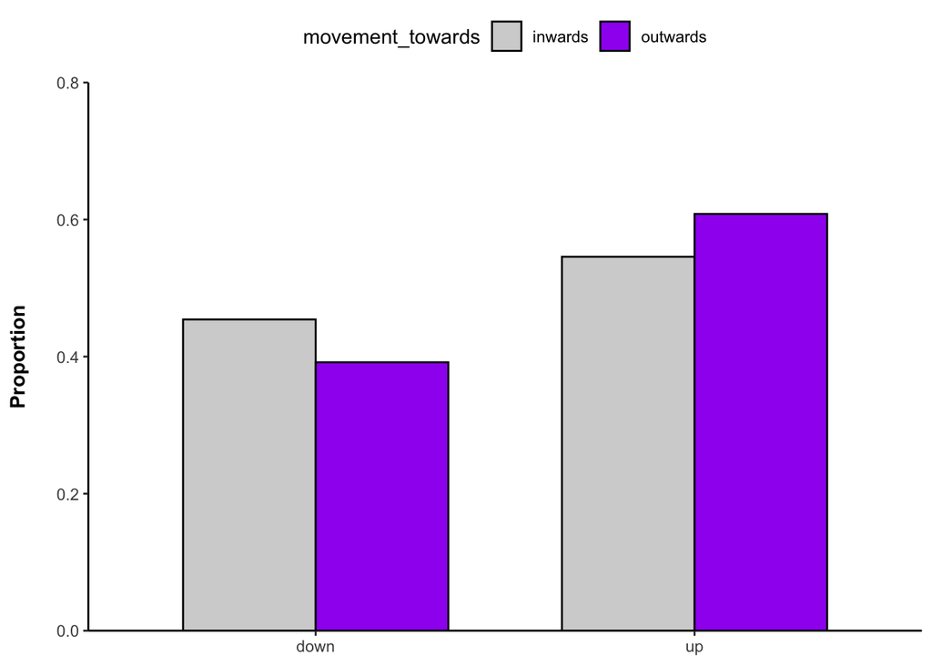

```r
# Plot basics:

diff_p <- diff_df |>
  count(movement_towards, rel_change_cat) |>
  filter(!is.na(rel_change_cat)) |>
  group_by(movement_towards) |>
  mutate(p = n / sum(n)) |>
  rename(`Relative change` = rel_change_cat) |>
  ggplot(aes(x = `Relative change`,
             fill = movement_towards, y = p)) +
  geom_col(position = 'dodge',
           col = 'black',
           width = 0.7)

# Axes and labels:

diff_p <- diff_p +
  scale_y_continuous(expand = c(0, 0),
                     limits = c(0, 0.8),
                     breaks = seq(0, 0.8, 0.2)) +
  scale_fill_manual(values = c('lightgrey', 'purple')) +
  xlab(NULL) +
  ylab('Proportion')

# Cosmetics:

diff_p <- diff_p +
  theme_classic() +
  theme(legend.position = 'top',
        axis.title.y = element_text(margin = margin(r = 15),
                                    face = 'bold'),
        axis.title.x = element_text(face = 'bold'))

# Show and save:

diff_p
```

```r
ggsave(plot = diff_p,
       file = '../figures/up_down_barplot.pdf',
       width = 3.5, height = 3.5)
ggsave(plot = diff_p,
       file = '../figures/png/up_down_barplot.png',
       width = 3.5, height = 3.5)
```

Look at how many times does it go up or down as a function of the `movement_towards` factor:

```r
diff_df |>
  count(movement_towards, rel_change_cat) |>
  filter(!is.na(rel_change_cat)) |>
  group_by(movement_towards) |>
  mutate(prop = n / sum(n),
         prop = round(prop, 2),
         percentage = str_c(prop * 100, '%'))
```

```
## # A tibble: 4 × 5
## # Groups:   movement_towards [2]
##   movement_towards rel_change_cat     n  prop percentage
##   <chr>            <chr>          <int> <dbl> <chr>
## 1 inwards          down            2116  0.45 45%
## 2 inwards          up              2542  0.55 55%
## 3 outwards         down            1830  0.39 39%
## 4 outwards         up              2841  0.61 61%
```

Quick-and-dirty bar plot of this:

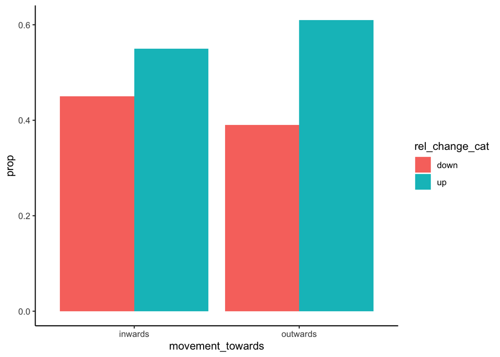

```r
#

diff_df |>
  count(movement_towards, rel_change_cat) |>
  filter(!is.na(rel_change_cat)) |>
  group_by(movement_towards) |>
  mutate(prop = n / sum(n),
         prop = round(prop, 2),
         percentage = str_c(prop * 100, '%')) |>
  ggplot(aes(x = movement_towards, fill = rel_change_cat,
             y = prop)) +
  geom_col(position = 'dodge') +
  theme_classic()
```

## 10.4 Logistic regression: main model

To model this, we need a new weakly informative prior adapted for logistic regression coefficients. Here, we’ll simply follow the advice by Gelman et al. (2008) to use a Cauchy prior centered at zero with scale = 2.5.

```r
logistic_priors <- c(prior(cauchy(0, 2.5), class = b))
```

For the logistic regression model, we need to code things as a factor or numeric variable:

```r
diff_df <- mutate(diff_df,
                  rel_change_cat = factor(rel_change_cat,
                                          levels = c('down', 'up')))
```

Create a logistic regression model for this:

```r
relative_mdl <- brm(rel_change_cat ~ 1 +
                      movement_towards +
                      (1 + movement_towards|id),
                    # Other settings:

                    data = diff_df,
                    family = bernoulli,
                    prior = logistic_priors,

                    # MCMC settings:

                    cores = 4, init = 0, control = mcmc_controls,
                    warmup = 3000, iter = 5000, chains = 4)

# Save:

save(relative_mdl,
     file = '../models/relative_mdl.RData')
```

Load:

```r
load('../models/relative_mdl.RData')
```

Posterior predictive checks:

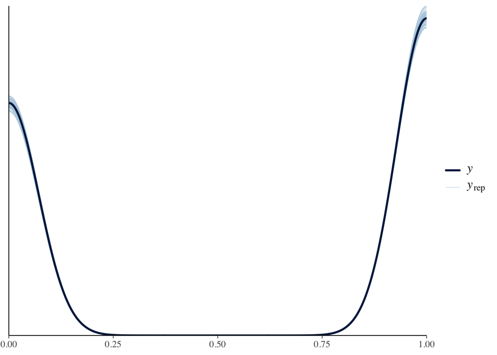

```r
pp_check(relative_mdl, ndraws = 100)
```

Show the model:

```r
relative_mdl
```

```
##  Family: bernoulli
##   Links: mu = logit
## Formula: rel_change_cat ~ 1 + movement_towards + (1 + movement_towards | id)
##    Data: diff_df (Number of observations: 9329)
##   Draws: 4 chains, each with iter = 5000; warmup = 3000; thin = 1;
##          total post-warmup draws = 8000
##
## Multilevel Hyperparameters:
## ~id (Number of levels: 120)
##                                         Estimate Est.Error l-95% CI u-95% CI
## sd(Intercept)                               0.37      0.05     0.29     0.47
## sd(movement_towardsoutwards)                0.44      0.07     0.31     0.57
## cor(Intercept,movement_towardsoutwards)    -0.83      0.07    -0.94    -0.66
##                                         Rhat Bulk_ESS Tail_ESS
## sd(Intercept)                           1.00     2992     4365
## sd(movement_towardsoutwards)            1.00     2676     3989
## cor(Intercept,movement_towardsoutwards) 1.00     3247     3996
##
## Regression Coefficients:
##                          Estimate Est.Error l-95% CI u-95% CI Rhat Bulk_ESS
## Intercept                    0.19      0.05     0.10     0.28 1.00     3923
## movement_towardsoutwards     0.26      0.06     0.15     0.37 1.00     4668
##                          Tail_ESS
## Intercept                    5256
## movement_towardsoutwards     5980
##
## Draws were sampled using sampling(NUTS). For each parameter, Bulk_ESS
## and Tail_ESS are effective sample size measures, and Rhat is the potential
## scale reduction factor on split chains (at convergence, Rhat = 1).
```

Test hypothesis:

```r
hypothesis(relative_mdl, 'movement_towardsoutwards > 0')
```

```
## Hypothesis Tests for class b:
##                 Hypothesis Estimate Est.Error CI.Lower CI.Upper Evid.Ratio
## 1 (movement_towards... > 0     0.26      0.06     0.16     0.35        Inf
##   Post.Prob Star
## 1         1    *
## ---
## 'CI': 90%-CI for one-sided and 95%-CI for two-sided hypotheses.
## '*': For one-sided hypotheses, the posterior probability exceeds 95%;
## for two-sided hypotheses, the value tested against lies outside the 95%-CI.
## Posterior probabilities of point hypotheses assume equal prior probabilities.
```

Nice.

How much variance does this model describe?

```r
bayes_R2(relative_mdl)
```

```
##      Estimate   Est.Error       Q2.5      Q97.5
## R2 0.02646602 0.003928933 0.01911707 0.03452287
```

Very small amount.

## 10.5 Language interaction

We also want to assess here whether language played a role. So let’s build the model with the interaction. For this, we need to first re-establish language column for this dataset:

```r
diff_df <- mutate(diff_df,
                  language = str_split(id, '_', simplify = TRUE)[, 1])
```

Contrast code this (sum coding) for more interpretable coefficients:

```r
# Make into factor:

diff_df <- mutate(diff_df,
             movement_towards_c = factor(movement_towards, levels = c('outwards', 'inwards')),
             language_c = factor(language, levels = c('italian', 'english')))

# Sum-code:

contrasts(diff_df$movement_towards_c) <- contr.sum(2)
contrasts(diff_df$language_c) <- contr.sum(2)

# Check:

contrasts(diff_df$movement_towards_c)
```

```
##          [,1]
## outwards    1
## inwards    -1
```

```r
contrasts(diff_df$language_c)
```

```
##         [,1]
## italian    1
## english   -1
```

Then run the model with the interaction:

```r
# Refit the model:

relative_interaction_mdl <- brm(rel_change_cat ~ 1 +
                                  language_c +
                                  movement_towards_c +
                                  language_c:movement_towards_c +
                                  (1 + movement_towards_c|id),
                    # Other settings:

                    data = diff_df,
                    family = bernoulli,
                    prior = logistic_priors,

                    # MCMC settings:

                    cores = 4, init = 0, control = mcmc_controls,
                    warmup = 3000, iter = 5000, chains = 4)

# Save:

save(relative_interaction_mdl,
     file = '../models/relative_interaction_mdl.RData')
```

Load:

```r
load('../models/relative_interaction_mdl.RData')
```

Show:

```r
relative_interaction_mdl
```

```
##  Family: bernoulli
##   Links: mu = logit
## Formula: rel_change_cat ~ 1 + language_c + movement_towards_c + language_c:movement_towards_c + (1 + movement_towards_c | id)
##    Data: diff_df (Number of observations: 9329)
##   Draws: 4 chains, each with iter = 5000; warmup = 3000; thin = 1;
##          total post-warmup draws = 8000
##
## Multilevel Hyperparameters:
## ~id (Number of levels: 120)
##                                    Estimate Est.Error l-95% CI u-95% CI Rhat
## sd(Intercept)                          0.22      0.03     0.16     0.29 1.00
## sd(movement_towards_c1)                0.23      0.03     0.16     0.29 1.00
## cor(Intercept,movement_towards_c1)    -0.44      0.19    -0.79    -0.06 1.00
##                                    Bulk_ESS Tail_ESS
## sd(Intercept)                          3099     4381
## sd(movement_towards_c1)                3509     4006
## cor(Intercept,movement_towards_c1)     1126     1392
##
## Regression Coefficients:
##                                 Estimate Est.Error l-95% CI u-95% CI Rhat
## Intercept                           0.32      0.03     0.26     0.38 1.00
## language_c1                         0.03      0.03    -0.03     0.09 1.00
## movement_towards_c1                 0.13      0.03     0.07     0.19 1.00
## language_c1:movement_towards_c1    -0.01      0.03    -0.07     0.05 1.00
##                                 Bulk_ESS Tail_ESS
## Intercept                           5453     6146
## language_c1                         5086     5397
## movement_towards_c1                 5522     5952
## language_c1:movement_towards_c1     5625     5878
##
## Draws were sampled using sampling(NUTS). For each parameter, Bulk_ESS
## and Tail_ESS are effective sample size measures, and Rhat is the potential
## scale reduction factor on split chains (at convergence, Rhat = 1).
```

Assess interaction with posterior:

```r
hypothesis(relative_interaction_mdl,
           'language_c1 > 0')
```

```
## Hypothesis Tests for class b:
##          Hypothesis Estimate Est.Error CI.Lower CI.Upper Evid.Ratio Post.Prob
## 1 (language_c1) > 0     0.03      0.03    -0.02     0.08       5.86      0.85
##   Star
## 1
## ---
## 'CI': 90%-CI for one-sided and 95%-CI for two-sided hypotheses.
## '*': For one-sided hypotheses, the posterior probability exceeds 95%;
## for two-sided hypotheses, the value tested against lies outside the 95%-CI.
## Posterior probabilities of point hypotheses assume equal prior probabilities.
```

```r
hypothesis(relative_interaction_mdl,
           'movement_towards_c1 > 0')
```

```
## Hypothesis Tests for class b:
##                 Hypothesis Estimate Est.Error CI.Lower CI.Upper Evid.Ratio
## 1 (movement_towards... > 0     0.13      0.03     0.08     0.18        Inf
##   Post.Prob Star
## 1         1    *
## ---
## 'CI': 90%-CI for one-sided and 95%-CI for two-sided hypotheses.
## '*': For one-sided hypotheses, the posterior probability exceeds 95%;
## for two-sided hypotheses, the value tested against lies outside the 95%-CI.
## Posterior probabilities of point hypotheses assume equal prior probabilities.
```

```r
hypothesis(relative_interaction_mdl,
           'language_c1:movement_towards_c1 < 0')
```

```
## Hypothesis Tests for class b:
##                 Hypothesis Estimate Est.Error CI.Lower CI.Upper Evid.Ratio
## 1 (language_c1:move... < 0    -0.01      0.03    -0.06     0.04       1.52
##   Post.Prob Star
## 1       0.6
## ---
## 'CI': 90%-CI for one-sided and 95%-CI for two-sided hypotheses.
## '*': For one-sided hypotheses, the posterior probability exceeds 95%;
## for two-sided hypotheses, the value tested against lies outside the 95%-CI.
## Posterior probabilities of point hypotheses assume equal prior probabilities.
```

Nothing much going on here for the interaction, but highly certain gesture effect and relatively more uncertain language effect. How certain are we in the gesture effect being larger than the language effect?

```r
hypothesis(relative_interaction_mdl,
           'movement_towards_c1 > language_c1')
```

```
## Hypothesis Tests for class b:
##                 Hypothesis Estimate Est.Error CI.Lower CI.Upper Evid.Ratio
## 1 (movement_towards... > 0      0.1      0.04     0.03     0.17     105.67
##   Post.Prob Star
## 1      0.99    *
## ---
## 'CI': 90%-CI for one-sided and 95%-CI for two-sided hypotheses.
## '*': For one-sided hypotheses, the posterior probability exceeds 95%;
## for two-sided hypotheses, the value tested against lies outside the 95%-CI.
## Posterior probabilities of point hypotheses assume equal prior probabilities.
```

99% certain.

Get all the posterior values for the three fixed effects coefficients:

```r
group_posts <- as_draws_df(relative_interaction_mdl) |>
  select(b_language_c1:`b_language_c1:movement_towards_c1`) |>
  pivot_longer(b_language_c1:`b_language_c1:movement_towards_c1`,
               values_to = 'estimate',
               names_to = 'coefficient') |>
  mutate(coefficient = if_else(coefficient == 'b_movement_towards_c1',
                               'gesture effect', coefficient),
         coefficient = if_else(coefficient == 'b_language_c1',
                               'language effect', coefficient),
         coefficient = if_else(coefficient == 'b_language_c1:movement_towards_c1',
                               'gesture * language interaction', coefficient))
# Show:

group_posts
```

```
## # A tibble: 24,000 × 2
##    coefficient                    estimate
##    <chr>                             <dbl>
##  1 language effect                 -0.0352
##  2 gesture effect                   0.152
##  3 gesture * language interaction  -0.0150
##  4 language effect                  0.0688
##  5 gesture effect                   0.142
##  6 gesture * language interaction  -0.0200
##  7 language effect                  0.0161
##  8 gesture effect                   0.140
##  9 gesture * language interaction  -0.0325
## 10 language effect                  0.0407
## # ℹ 23,990 more rows
```

Create a density plot of the three fixed effects.

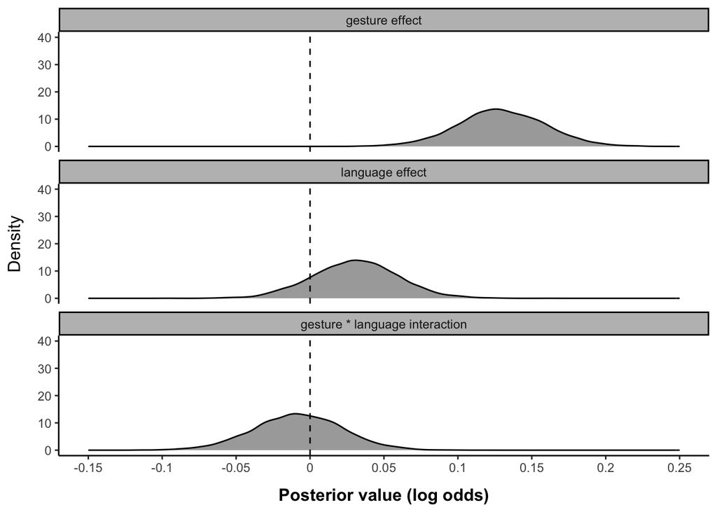

```r
# Order of levels:

fac_order <- c('gesture effect', 'language effect',
               'gesture * language interaction')

# Plot basics:

diff_p <- group_posts |>
  mutate(coefficient = factor(coefficient, levels = fac_order)) |>
  ggplot(aes(x = estimate)) +
  facet_wrap(~coefficient, nrow = 3) +
  geom_density(fill = 'darkgrey')

# Axes and labels:

diff_p <- diff_p +
  geom_vline(xintercept = 0, linetype = 'dashed') +
  scale_x_continuous(limits = c(-0.15, 0.25),
                     breaks = seq(-0.15, 0.25, 0.05),
                     labels = round(seq(-0.15, 0.25, 0.05), 2)) +
  scale_y_continuous(limits = c(0, 40),
                     breaks = seq(0, 40, 10)) +
  xlab('Posterior value (log odds)') +
  ylab('Density')

# Cosmetics:

diff_p <- diff_p +
  theme_classic() +
  theme(axis.title.y = element_text(margin = margin(r = 10),
                                    size = 12),
        axis.title.x = element_text(face = 'bold', size = 12,
                                    margin = margin(t = 10)),
        strip.background = element_rect(fill = 'grey'))

# Show and save:

diff_p
```

```r
ggsave(plot = diff_p,
       file = '../figures/group_mdl_posterior_effect_relative_difference.pdf',
       width = 4, height = 6.5)
ggsave(plot = diff_p,
       file = '../figures/png/group_mdl_posterior_effect_relative_difference.png',
       width = 4, height = 6.5)
```

## 10.6 Model with BAG interaction

We need to merge the `SNS` and `BAG` scales back into the new tibble with the relative changes.

```r
diff_df <- left_join(diff_df,
                     distinct(df, id, BAG_c, SNS_c))
```

The model with the BAG interaction:

```r
# Refit the model:

relative_BAG_mdl <- brm(rel_change_cat ~ 1 +
                          BAG_c +
                          movement_towards_c +
                          BAG_c:movement_towards_c +
                          (1 + movement_towards_c|id),

                        # Other settings:

                        data = diff_df,
                        family = bernoulli,
                        prior = logistic_priors,

                        # MCMC settings:

                        cores = 4, init = 0, control = mcmc_controls,
                        warmup = 3000, iter = 5000, chains = 4)

# Save:

save(relative_BAG_mdl,
     file = '../models/relative_BAG_mdl.RData')
```

Load:

```r
load('../models/relative_BAG_mdl.RData')
```

Show the model:

```r
relative_BAG_mdl
```

```
##  Family: bernoulli
##   Links: mu = logit
## Formula: rel_change_cat ~ 1 + BAG_c + movement_towards_c + BAG_c:movement_towards_c + (1 + movement_towards_c | id)
##    Data: diff_df (Number of observations: 9329)
##   Draws: 4 chains, each with iter = 5000; warmup = 3000; thin = 1;
##          total post-warmup draws = 8000
##
## Multilevel Hyperparameters:
## ~id (Number of levels: 120)
##                                    Estimate Est.Error l-95% CI u-95% CI Rhat
## sd(Intercept)                          0.22      0.03     0.16     0.29 1.00
## sd(movement_towards_c1)                0.22      0.03     0.16     0.29 1.00
## cor(Intercept,movement_towards_c1)    -0.46      0.19    -0.81    -0.08 1.00
##                                    Bulk_ESS Tail_ESS
## sd(Intercept)                          3721     4623
## sd(movement_towards_c1)                3433     4274
## cor(Intercept,movement_towards_c1)     1807     2292
##
## Regression Coefficients:
##                           Estimate Est.Error l-95% CI u-95% CI Rhat Bulk_ESS
## Intercept                     0.32      0.03     0.26     0.37 1.00     5327
## BAG_c                         0.02      0.03    -0.04     0.08 1.00     5819
## movement_towards_c1           0.13      0.03     0.07     0.19 1.00     6499
## BAG_c:movement_towards_c1     0.04      0.03    -0.02     0.10 1.00     6305
##                           Tail_ESS
## Intercept                     5759
## BAG_c                         6362
## movement_towards_c1           6406
## BAG_c:movement_towards_c1     6336
##
## Draws were sampled using sampling(NUTS). For each parameter, Bulk_ESS
## and Tail_ESS are effective sample size measures, and Rhat is the potential
## scale reduction factor on split chains (at convergence, Rhat = 1).
```

Assess interaction with posterior:

```r
hypothesis(relative_BAG_mdl,
           'BAG_c:movement_towards_c1 > 0')
```

```
## Hypothesis Tests for class b:
##                 Hypothesis Estimate Est.Error CI.Lower CI.Upper Evid.Ratio
## 1 (BAG_c:movement_t... > 0     0.04      0.03    -0.01     0.09       9.27
##   Post.Prob Star
## 1       0.9
## ---
## 'CI': 90%-CI for one-sided and 95%-CI for two-sided hypotheses.
## '*': For one-sided hypotheses, the posterior probability exceeds 95%;
## for two-sided hypotheses, the value tested against lies outside the 95%-CI.
## Posterior probabilities of point hypotheses assume equal prior probabilities.
```

## 10.7 Model with SNS interaction

Model with the SNS interaction:

```r
# Refit the model:

relative_SNS_mdl <- brm(rel_change_cat ~ 1 +
                          SNS_c +
                          movement_towards_c +
                          SNS_c:movement_towards_c +
                          (1 + movement_towards_c|id),

                        # Other settings:

                        data = diff_df,
                        family = bernoulli,
                        prior = logistic_priors,

                        # MCMC settings:

                        cores = 4, init = 0, control = mcmc_controls,
                        warmup = 3000, iter = 5000, chains = 4)

# Save:

save(relative_SNS_mdl,
     file = '../models/relative_SNS_mdl.RData')
```

Load:

```r
load('../models/relative_SNS_mdl.RData')
```

Show the model:

```r
relative_SNS_mdl
```

```
##  Family: bernoulli
##   Links: mu = logit
## Formula: rel_change_cat ~ 1 + SNS_c + movement_towards_c + SNS_c:movement_towards_c + (1 + movement_towards_c | id)
##    Data: diff_df (Number of observations: 9329)
##   Draws: 4 chains, each with iter = 5000; warmup = 3000; thin = 1;
##          total post-warmup draws = 8000
##
## Multilevel Hyperparameters:
## ~id (Number of levels: 120)
##                                    Estimate Est.Error l-95% CI u-95% CI Rhat
## sd(Intercept)                          0.22      0.03     0.16     0.29 1.00
## sd(movement_towards_c1)                0.23      0.03     0.16     0.29 1.00
## cor(Intercept,movement_towards_c1)    -0.42      0.19    -0.78    -0.03 1.00
##                                    Bulk_ESS Tail_ESS
## sd(Intercept)                          3485     4521
## sd(movement_towards_c1)                3325     5263
## cor(Intercept,movement_towards_c1)     1236     1007
##
## Regression Coefficients:
##                           Estimate Est.Error l-95% CI u-95% CI Rhat Bulk_ESS
## Intercept                     0.32      0.03     0.26     0.38 1.00     4867
## SNS_c                         0.03      0.03    -0.03     0.09 1.00     4613
## movement_towards_c1           0.13      0.03     0.07     0.19 1.00     5093
## SNS_c:movement_towards_c1    -0.03      0.03    -0.09     0.03 1.00     4765
##                           Tail_ESS
## Intercept                     5251
## SNS_c                         5056
## movement_towards_c1           5651
## SNS_c:movement_towards_c1     5507
##
## Draws were sampled using sampling(NUTS). For each parameter, Bulk_ESS
## and Tail_ESS are effective sample size measures, and Rhat is the potential
## scale reduction factor on split chains (at convergence, Rhat = 1).
```

Assess interaction with posterior:

```r
hypothesis(relative_SNS_mdl,
           'SNS_c:movement_towards_c1 < 0')
```

```
## Hypothesis Tests for class b:
##                 Hypothesis Estimate Est.Error CI.Lower CI.Upper Evid.Ratio
## 1 (SNS_c:movement_t... < 0    -0.03      0.03    -0.08     0.02        4.8
##   Post.Prob Star
## 1      0.83
## ---
## 'CI': 90%-CI for one-sided and 95%-CI for two-sided hypotheses.
## '*': For one-sided hypotheses, the posterior probability exceeds 95%;
## for two-sided hypotheses, the value tested against lies outside the 95%-CI.
## Posterior probabilities of point hypotheses assume equal prior probabilities.
```

## 10.8 Simple correlations for individual differences

Let’s look at the proportion of outwards trials that are “up” and correlate that (Spearman’s rho) with the BAG and SNS scores, in analogy to the simple correlation analysis for the absolute magnitude analysis.

```r
prop_df <- diff_df |>
  count(id, movement_towards, rel_change_cat) |>
  filter(!is.na(rel_change_cat)) |>
  filter(movement_towards == 'outwards') |>
  group_by(id) |>
  mutate(p = n / sum(n)) |>
  filter(rel_change_cat == 'up')

# Merge BAG and SNS back in there:

prop_df <- left_join(prop_df,
                     select(df_ppt_wide, id, BAG, SNS))
```

Perform correlations:

```r
# Difference score with BAG:

with(prop_df,
     cor.test(p, BAG, method = 'spearman'))
```

```
##
##  Spearman's rank correlation rho
##
## data:  p and BAG
## S = 251388, p-value = 0.1667
## alternative hypothesis: true rho is not equal to 0
## sample estimates:
##       rho
## 0.1270629
```

```r
# Difference score with SNS:

with(prop_df,
     cor.test(p, SNS, method = 'spearman'))
```

```
##
##  Spearman's rank correlation rho
##
## data:  p and SNS
## S = 288477, p-value = 0.9851
## alternative hypothesis: true rho is not equal to 0
## sample estimates:
##        rho
## -0.0017258
```

# 11 Other explorations

1. the first trial
2. the values 1 and 30 in particular
3. the impact of individual numbers
4. exploration of a possible MARC effect

Analyses 1) and 2) in particular are motivated post-hoc based on the fact that during data collection, we noticed that participants generated a high number of “1” or “30” responses on the first trial. We wanted to ensure that our results are not exclusively driven by the first trial, i.e., the same average result is found even if this is excluded, and even if the numbers 1 and 30 are excluded.

Analysis 3) is important as it could be possible that a subset of numbers are driving the effect.

Analysis 4) looks at the possibility of a MARC effect in this data where even numbers may be more likely for either outwards or inwards movements, but probably outwards, which would be a parity correspondence if we assume that outwards is easier and more normal than inwards.

## 11.1 Start number

Let’s look at what numbers are most often said on the first trial:

```r
df |>
  filter(trial == 1) |>
  count(number, sort = TRUE)
```

```
## # A tibble: 29 × 2
##    number     n
##     <dbl> <int>
##  1      1    19
##  2      2    14
##  3      4    10
##  4      3     9
##  5      5     8
##  6      7     8
##  7      6     6
##  8     21     5
##  9     11     4
## 10     30     4
## # ℹ 19 more rows
```

As can be seen, the number 1 was most frequently said on the first trial.

How does this differ by starting position?

```r
df |>
  filter(trial == 1) |>
  count(start_position, number, sort = TRUE)
```

```
## # A tibble: 45 × 3
##    start_position number     n
##    <chr>           <dbl> <int>
##  1 inwards             1    11
##  2 inwards             2     9
##  3 outwards            1     8
##  4 inwards             4     7
##  5 inwards             7     5
##  6 outwards            2     5
##  7 outwards            3     5
##  8 inwards             3     4
##  9 inwards             5     4
## 10 outwards            5     4
## # ℹ 35 more rows
```

Let’s look at what the results would be in the average without the first trial:

```r
df |>
  filter(trial != 1) |>
  group_by(movement) |>
  summarize(M = mean(number, na.rm = TRUE),
            SD = sd(number, na.rm = TRUE))
```

```
## # A tibble: 2 × 3
##   movement     M    SD
##   <chr>    <dbl> <dbl>
## 1 inwards   14.1  8.63
## 2 outwards  14.8  8.71
```

Same, which is re-assuring!

Let’s look at *only* the first trial, to see whether the effect is already there:

```r
df |>
  filter(trial == 1) |>
  group_by(movement) |>
  summarize(M = mean(number, na.rm = TRUE),
            SD = sd(number, na.rm = TRUE))
```

```
## # A tibble: 2 × 3
##   movement     M    SD
##   <chr>    <dbl> <dbl>
## 1 inwards   6.66  6.92
## 2 outwards 10.8   9.10
```

## 11.2 Numbers 1 and 30

Let’s look at how often the numbers 1 and 30 were said with outwards and inwards:

```r
df |>
  filter(number %in% c(1, 30)) |>
  count(number, movement) |>
  mutate(p = n / sum(n))
```

```
## # A tibble: 4 × 4
##   number movement     n     p
##    <dbl> <chr>    <int> <dbl>
## 1      1 inwards    220 0.255
## 2      1 outwards   196 0.227
## 3     30 inwards    201 0.233
## 4     30 outwards   247 0.286
```

Let’s incorporate trial into the picture, with a variable that codes for first trial versus all other trials:

```r
trial_range_tab <- df |>
  mutate(trial = if_else(trial == 1,
                         'first trial', 'later trials')) |>
  filter(number %in% c(1, 30)) |>
  count(trial, number, movement) |>
  group_by(trial, movement) |>
  mutate(p = n / sum(n))

# Show:

trial_range_tab
```

```
## # A tibble: 7 × 5
## # Groups:   trial, movement [4]
##   trial        number movement     n     p
##   <chr>         <dbl> <chr>    <int> <dbl>
## 1 first trial       1 inwards     11 1
## 2 first trial       1 outwards     8 0.667
## 3 first trial      30 outwards     4 0.333
## 4 later trials      1 inwards    209 0.510
## 5 later trials      1 outwards   188 0.436
## 6 later trials     30 inwards    201 0.490
## 7 later trials     30 outwards   243 0.564
```

Let’s look at the results without the numbers 1 and 30:

```r
df |>
  filter(!number %in% c(1, 30)) |>
  group_by(movement) |>
  summarize(M = mean(number, na.rm = TRUE),
            SD = sd(number, na.rm = TRUE))
```

```
## # A tibble: 2 × 3
##   movement     M    SD
##   <chr>    <dbl> <dbl>
## 1 inwards   13.9  7.85
## 2 outwards  14.6  7.89
```

## 11.3 Individual numbers

Count the number of cases for each number, separately for each movement:

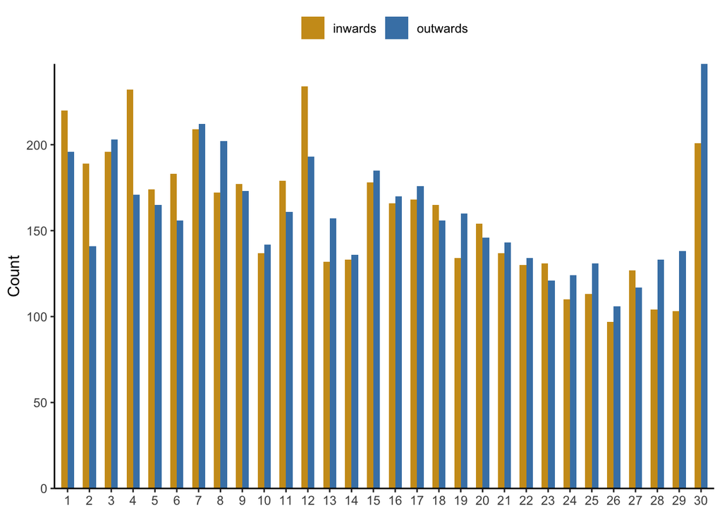

```r
# Plot basics:

bar_p <- df |>
  count(movement, number) |>
  filter(!is.na(number)) |>
  ggplot(aes(x = factor(number), y = n, fill = movement)) +
  geom_col(position = 'dodge',
           width = 0.6)

# Axes and labels:

bar_p <- bar_p +
  xlab(NULL) +
  ylab('Count') +
  scale_y_continuous(expand = c(0, 0)) +
  scale_fill_manual(values = c('goldenrod3', 'steelblue'))

# Cosmetics:

bar_p <- bar_p +
  theme_classic() +
  theme(legend.position = 'top',
        legend.title = element_blank())

# Show and save:

bar_p
```

```r
ggsave(plot = bar_p,
       file = '../figures/barplot.pdf',
       width = 10.5, height = 4.5)
ggsave(plot = bar_p,
       file = '../figures/png/barplot.png',
       width = 10.5, height = 4.5)
```

Another way of looking at this is to compute the proportion of cases for inwards and outwards, with stacked bar plots.

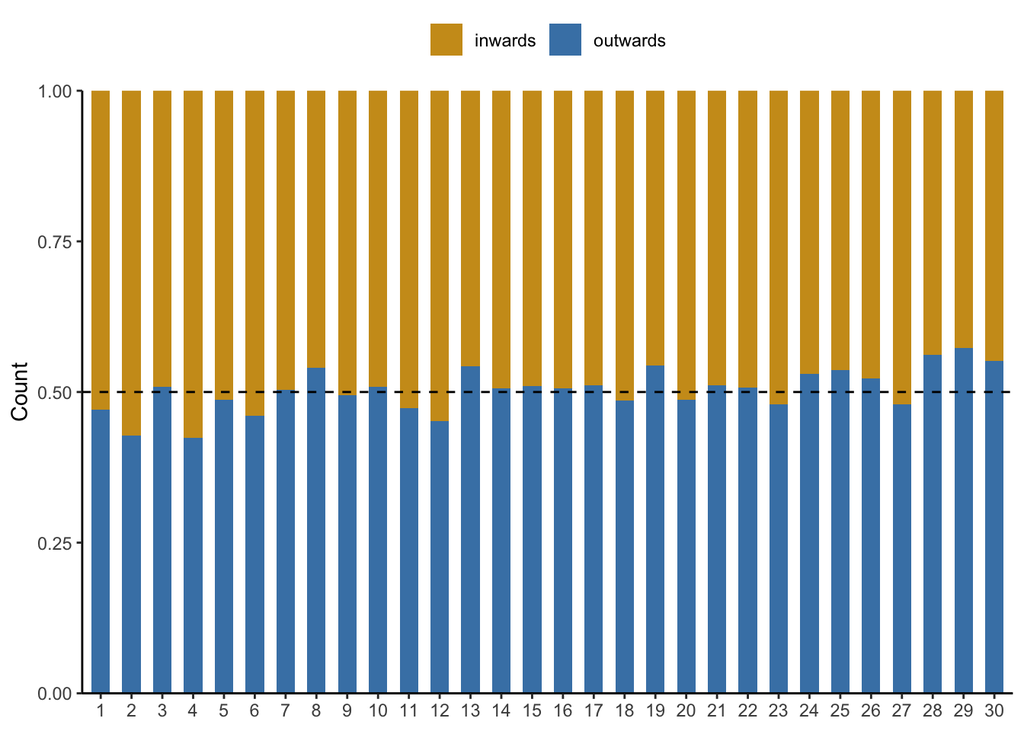

```r
# Plot basics:

bar_p <- df |>
  count(movement, number) |>
  filter(!is.na(number)) |>
  group_by(number) |>
  mutate(p = n / sum(n)) |>
  ggplot(aes(x = factor(number), y = p, fill = movement)) +
  geom_col(width = 0.6)

# Axes and labels:

bar_p <- bar_p +
  xlab(NULL) +
  ylab('Count') +
  geom_hline(yintercept = 0.5, linetype = 'dashed') +
  scale_y_continuous(expand = c(0, 0)) +
  scale_fill_manual(values = c('goldenrod3', 'steelblue'))

# Cosmetics:

bar_p <- bar_p +
  theme_classic() +
  theme(legend.position = 'top',
        legend.title = element_blank())

# Show and save:

bar_p
```

```r
ggsave(plot = bar_p,
       file = '../figures/stacked_barplot.pdf',
       width = 10.5, height = 4.5)
ggsave(plot = bar_p,
       file = '../figures/png/stacked_barplot.png',
       width = 10.5, height = 4.5)
```

Get the table of percentage differences outwards - inwards for each number.

```r
num_df <- df |>
  count(movement, number) |>
  filter(!is.na(number)) |>
  group_by(number) |>
  mutate(p = n / sum(n)) |>
  filter(movement == 'outwards') |>
  select(-movement)

# Show:

num_df |>
  print(n = Inf)
```

```
## # A tibble: 30 × 3
## # Groups:   number [30]
##    number     n     p
##     <dbl> <int> <dbl>
##  1      1   196 0.471
##  2      2   141 0.427
##  3      3   203 0.509
##  4      4   171 0.424
##  5      5   165 0.487
##  6      6   156 0.460
##  7      7   212 0.504
##  8      8   202 0.540
##  9      9   173 0.494
## 10     10   142 0.509
## 11     11   161 0.474
```

[output cut: 19 more lines]

We can perform a correlation of this (non-parametric) as a quick-and-dirty double-check of the correlation of “% outwards” and numerical magnitude.

```r
with(num_df,
     cor.test(number, p, method = 'spearman'))
```

```
##
##  Spearman's rank correlation rho
##
## data:  number and p
## S = 1898, p-value = 0.001019
## alternative hypothesis: true rho is not equal to 0
## sample estimates:
##       rho
## 0.5777531
```

Quite strongly correlated. Comforting to know!

What about this plot idea?

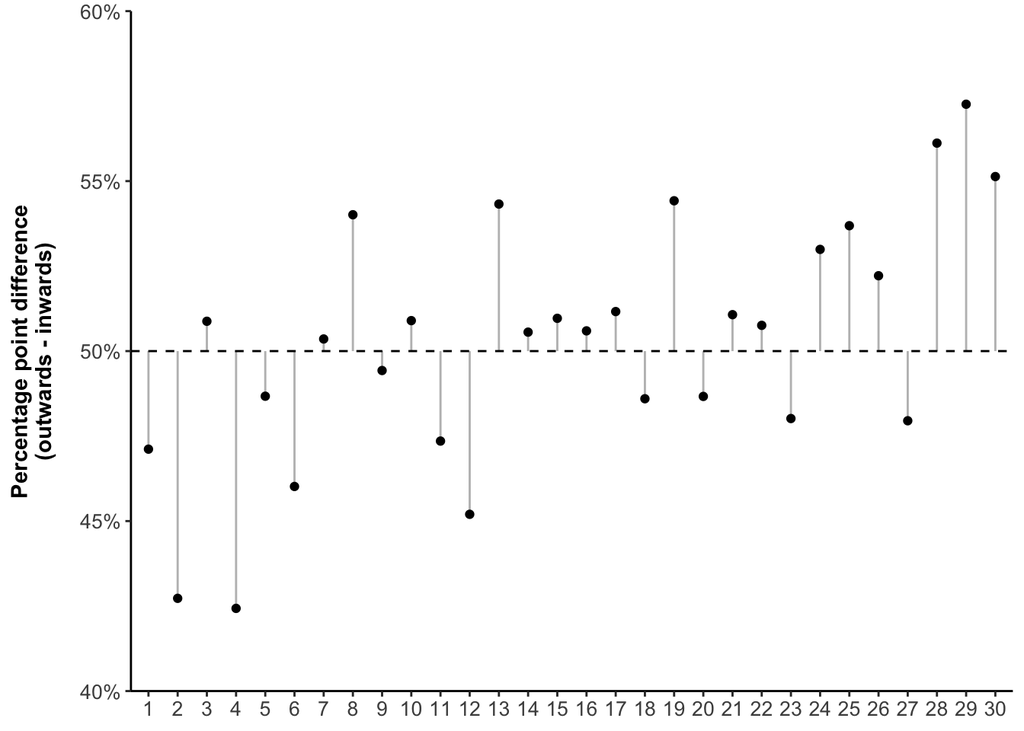

```r
# Plot basics:

dot_p <- num_df |>
  ggplot(aes(x = factor(number), y = p)) +
  geom_segment(aes(xend = factor(number), y = 0.5, yend = p),
               col = 'gray') +
  geom_point()

# Axes and labels:

dot_p <- dot_p +
  xlab(NULL) +
  ylab('Percentage point difference\n(outwards - inwards)') +
  geom_hline(yintercept = 0.5, linetype = 'dashed') +
  scale_y_continuous(expand = c(0, 0),
                     limits = c(0.4, 0.6),
                     breaks = seq(0.4, 0.6, 0.05),
                     labels = str_c(seq(40, 60, 5), '%')) +
  scale_fill_manual(values = c('goldenrod3', 'steelblue'))

# Cosmetics:

dot_p <- dot_p +
  theme_classic() +
  theme(legend.position = 'top',
        legend.title = element_blank(),
        axis.title.y = element_text(face = 'bold',
                                    margin = margin(r = 12)),
        axis.text.x = element_text(size = 10),
        axis.text.y = element_text(size = 10))

# Show and save:

dot_p
```

```r
ggsave(plot = dot_p,
       file = '../figures/number_dot_plot.pdf',
       width = 10.5, height = 4.5)
ggsave(plot = dot_p,
       file = '../figures/png/number_dot_plot.png',
       width = 10.5, height = 4.5)
```

## 11.4 MARC effect

Code for odd versus even numbers and make it into a factor for a logistic regression model:

```r
df <- mutate(df,
             parity = if_else(number %% 2 == 0, 'even', 'odd'),
             parity = factor(parity, levels = c('odd', 'even')))
```

Check descriptive proportions:

```r
df |>
  filter(!is.na(parity)) |>
  count(movement, parity) |>
  group_by(movement) |>
  mutate(prop = n / sum(n))
```

```
## # A tibble: 4 × 4
## # Groups:   movement [2]
##   movement parity     n  prop
##   <chr>    <fct>  <int> <dbl>
## 1 inwards  odd     2378 0.497
## 2 inwards  even    2407 0.503
## 3 outwards odd     2438 0.508
## 4 outwards even    2357 0.492
```

Pretty much nothing.

Build a logistic regression model for this:

```r
MARC_mdl <- brm(parity ~ 1 +
                  movement +
                  (1 + movement|id),

                # Params:

                data = df,
                family = bernoulli,
                stanvars = stanvars,

                # MCMC settings:

                cores = 4, init = 0, control = mcmc_controls,
                warmup = 3000, iter = 5000, chains = 4)

# Save:

save(MARC_mdl,
     file = '../models/MARC_mdl.RData')
```

Load the model for the markdown (the actual code chunks have been set to `eval = FALSE` as the models are precompiled).

```r
load('../models/MARC_mdl.RData')
```

Check model:

```r
MARC_mdl
```

```
##  Family: bernoulli
##   Links: mu = logit
## Formula: parity ~ 1 + movement + (1 + movement | id)
##    Data: df (Number of observations: 9580)
##   Draws: 4 chains, each with iter = 5000; warmup = 3000; thin = 1;
##          total post-warmup draws = 8000
##
## Multilevel Hyperparameters:
## ~id (Number of levels: 120)
##                                 Estimate Est.Error l-95% CI u-95% CI Rhat
## sd(Intercept)                       0.16      0.06     0.02     0.27 1.01
## sd(movementoutwards)                0.28      0.08     0.10     0.41 1.00
## cor(Intercept,movementoutwards)    -0.50      0.36    -0.90     0.56 1.00
##                                 Bulk_ESS Tail_ESS
## sd(Intercept)                       1154     1325
## sd(movementoutwards)                1078     1106
## cor(Intercept,movementoutwards)     1051     1003
##
## Regression Coefficients:
##                  Estimate Est.Error l-95% CI u-95% CI Rhat Bulk_ESS Tail_ESS
## Intercept            0.01      0.03    -0.05     0.08 1.00     9891     6649
## movementoutwards    -0.05      0.05    -0.14     0.05 1.00     9979     6466
##
## Draws were sampled using sampling(NUTS). For each parameter, Bulk_ESS
## and Tail_ESS are effective sample size measures, and Rhat is the potential
## scale reduction factor on split chains (at convergence, Rhat = 1).
```

Test main hypothesis:

```r
hypothesis(MARC_mdl, 'movementoutwards < 0')
```

```
## Hypothesis Tests for class b:
##               Hypothesis Estimate Est.Error CI.Lower CI.Upper Evid.Ratio
## 1 (movementoutwards) < 0    -0.05      0.05    -0.13     0.03       4.77
##   Post.Prob Star
## 1      0.83
## ---
## 'CI': 90%-CI for one-sided and 95%-CI for two-sided hypotheses.
## '*': For one-sided hypotheses, the posterior probability exceeds 95%;
## for two-sided hypotheses, the value tested against lies outside the 95%-CI.
## Posterior probabilities of point hypotheses assume equal prior probabilities.
```

Not much going on. Although we can be 83% certain that for outwards gestures, there’s on average more odd responses.

# 12 Concluding remarks

Overall, we seem to have a reliable gesture effect that emerges under a number of different analysis approaches, using absolute magnitudes in a mixed model or relative changes in a logistic regression model. The effect also emerges under some simple NHST analyses. However, it absolutely has to be emphasized that this is clearly a very small effect overall, as revealed through the descriptive averages, Cohen’s d, and the fact that in at least one of the analyses, the expected variation due to gesture does not even exceed the completley unexpected variation due to speaking group.

In terms of individual differences, there are very very very weak effects that only emerge under certain analyses approaches. The correlations with SNS or BAG are barely worth mentioning in terms of their magnitude. Here, we conclude that the two particular individual difference measures we decided to look at do not matter much for this phenomenon.

This completes this analysis.